# DATA SCIENCE COURSEWORK NUMBER 2

### by Hermine Tranié, CID: 01400919

# TASK 1: NEURAL NETWORKS

# 1.0 Load data

First, we start by loading the necessary packages

```python
import numpy as np
import pandas as pd
import tensorflow as tf
import matplotlib.pyplot as plt
import seaborn as sns
```

### Preview data samples

```python
(x_train, y_train), (x_val, y_val) = tf.keras.datasets.cifar10.load_data()
x_train = x_train.astype('float32') / 255
x_val = x_val.astype('float32') / 255
```

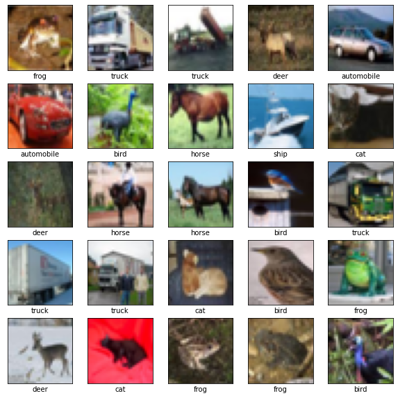

```python
class_names = ['airplane', 'automobile', 'bird', 'cat', 'deer',
               'dog', 'frog', 'horse', 'ship', 'truck']

plt.figure(figsize=(10,10))
for i in range(25):
    plt.subplot(5,5,i+1)
    plt.xticks([])
    plt.yticks([])
    plt.grid(False)
    plt.imshow(x_train[i], cmap=plt.cm.binary)
    # The CIFAR labels happen to be arrays, which is why you need the extra index
    plt.xlabel(class_names[y_train[i][0]])
plt.show()
```

Thanks to the sample of our data, we can see that the dataset is comprised of 10 different classes to identify, namely airplane, automobile, bird, cat, deer, dog, frog, horse, ship, truck. Our goal throughout this exercise is to implement two different methods of neural networks to maximise the accuracy of the detection of these objects. We will be implementing:

1. a Multilayer Perceptron with 5 hidden layers coded using NumPy only
2. a Convolutional Neural Network with 4 hidden layers coded using Tensorflow

### Data exploration

First of all, we load the data, as instructed and we resize if needed.

```python
def load_data():
    (x_train, y_train), (x_val, y_val) = tf.keras.datasets.cifar10.load_data()
    x_train = x_train.astype('float32') / 255
    x_val = x_val.astype('float32') / 255

    # convert labels to categorical samples
    y_train = tf.keras.utils.to_categorical(y_train, num_classes=10)
    y_val = tf.keras.utils.to_categorical(y_val, num_classes=10)
    return ((x_train, y_train), (x_val, y_val))

(x_train, y_train), (x_val, y_val) = load_data()
```

```python
print('The shape of training predictors is:', x_train.shape)
print('The shape of training predictors is:', y_train.shape)
print('The shape of validation predictors is:', x_val.shape)
print('The shape of validation predictors is:', y_val.shape)
```

```
The shape of training predictors is: (50000, 32, 32, 3)
The shape of training predictors is: (50000, 10)
The shape of validation predictors is: (10000, 32, 32, 3)
The shape of validation predictors is: (10000, 10)
```

```python
# Resize the predictors shape in order to feed to the algorithm
x_train = x_train.reshape([x_train.shape[0],-1])
x_val = x_val.reshape([x_val.shape[0],-1])
```

```python
x_train
```

```
array([[0.23137255, 0.24313726, 0.24705882, ..., 0.48235294, 0.36078432,
        0.28235295],
       [0.6039216 , 0.69411767, 0.73333335, ..., 0.56078434, 0.52156866,
        0.5647059 ],
       [1.        , 1.        , 1.        , ..., 0.3137255 , 0.3372549 ,
        0.32941177],
       ...,
       [0.13725491, 0.69803923, 0.92156863, ..., 0.04705882, 0.12156863,
        0.19607843],
       [0.7411765 , 0.827451  , 0.9411765 , ..., 0.7647059 , 0.74509805,
        0.67058825],
       [0.8980392 , 0.8980392 , 0.9372549 , ..., 0.6392157 , 0.6392157 ,
        0.6313726 ]], dtype=float32)
```

```python
print('The shape of training predictors is:', x_train.shape)
print('The shape of validation predictors is:', x_val.shape)
```

```
The shape of training predictors is: (50000, 3072)
The shape of validation predictors is: (10000, 3072)
```

# 1.1 Multi-layer perceptron

## 1.1.0 Shuffle data

First, we want define a function to shuffle the data, to pick our batches selection as random as possible at the beginning of every epoch.

```python
### SHUFFLE DATA ###

shuffle = np.random.permutation(range(x_train.shape[0]))
x_train = x_train[shuffle]
y_train = y_train[shuffle]
```

```python
x_train
```

```
array([[0.9411765 , 0.9372549 , 0.9529412 , ..., 0.95686275, 0.95686275,
        0.9529412 ],
       [0.4392157 , 0.40784314, 0.39607844, ..., 0.03137255, 0.02352941,
        0.01568628],
       [0.04705882, 0.05882353, 0.0627451 , ..., 0.08235294, 0.08235294,
        0.09019608],
       ...,
       [0.81960785, 0.9137255 , 0.9843137 , ..., 0.42352942, 0.54509807,
        0.6784314 ],
       [0.23137255, 0.22745098, 0.21176471, ..., 0.48235294, 0.32156864,
        0.23137255],
       [0.1764706 , 0.16078432, 0.12941177, ..., 0.31764707, 0.30980393,
        0.27058825]], dtype=float32)
```

## 1.1.1 Train multi-layer perceptron with LR=0.01 on 40 epochs

First let's randomly initialize our bias and our weights.

```python
### Parameters initialization of MLP as in CT ###

var0 = 2. / (3072 + 400)
W0 = np.random.randn(3072, 400) * np.sqrt(var0) # initial size of image
b0 = np.zeros(400)

var1 = 2. / (400 + 400)
W1 = np.random.randn(400, 400) * np.sqrt(var1)
b1 = np.zeros(400)

var2 = 2. / (400 + 400)
W2 = np.random.randn(400,400) * np.sqrt(var2)
b2 = np.zeros(400)

var3 = 2. / (400 + 400)
W3 = np.random.randn(400,400) * np.sqrt(var3)
b3 = np.zeros(400)

var4 = 2. / (400 + 400)
W4 = np.random.randn(400,400) * np.sqrt(var4)
b4 = np.zeros(400)

var5 = 2. / (10 + 400)
W5 = np.random.randn(400,10) * np.sqrt(var5) # output value of 10 neurons
b5 = np.zeros(10)
```

Note that by initializing our paremeters, we can compute the number of parameters that our model is going to deal with. We have the weights $W_i$ and bias $b_i$. The total number of parameters of our model is: $\sum_{i=0}^5 size(W_i) + size(b_i) = 400(3072 + 4*400 + 10) + 5*400 + 10 = 1,874,810$. So we have around 1.8 million parameters in our Multilayer perceptron.

Now let's define functions in order to implement our Multilayer Perceptron with Stochastic Gradient Descent (SGD) and cross-entropy loss as follows:

- 5 hidden layers (400 neurons each)\ --> tanh activation function
- 1 output layer (10 neurons)\ --> softmax activation function

We will train our model on batches of 128 points with a learning rate of 0.01 for 40 epochs.

Our main functions include:

1. the function *dense* which implements the dense layer transformation to obtain the pre-activation values (from CT)
2. the activation functions *tanh* and *softmax* and the derivative of tanh: *tanh_derivative*
3. the function *cross_entropy* which computes the cross entropy loss of the function
4. the function *output_error* which compute the error [8]
5. the function *backpropagate* which implement the backpropagation algorithm (from CT)
6. the function *MLP* which computes the output predicted vector of probabilities after having gone through the whole network
7. the function *grads* which computes the gradients for each weights and bias

This whole set up of functions will then allow us to build our model.

```python
### Define dense function for dense layer transformation to obtain the pre-activation values ###

def dense(a, W, b):

    # a: K x a_in array of inputs
    # W: a_in x a_out array for kernel matrix parameters
    # b: Length a_out 1-D array for bias parameters
    # returns: K x a_out output array

    h = b + a @ W
    return h
```

```python
### Define activation functions: tanh and softmax ###

def tanh(x): # define tanh activation function

    return np.tanh(x)

def tanh_derivative(x): # define tanh derivative

    return 1 - tanh(x)**2

def softmax(x): # define output layer activation function

    return (np.exp(x)) / (np.exp(x).sum(axis = 1)[:, None])
```

In order to put some background explanation for our activation functions (especially softmax, because tanh derivative is quite straight-forward):

We won't be computing the derivative of softmax directly, but instead, we'll combine it with the loss function: cross-entropy, as suggested by [8]:

First, we define the cross entropy $CE=-\sum_j t_j \log(o_j)$ with $t_j$ is the target output for neuron j (y_val) and $o_j$ is the output of the neuron (y_pred).

We get that $\frac{\partial CE}{\partial o_j} = -\frac{t_j}{o_j}$

Note that for our final loss is computed with the softmax activation function defined as follows: $ o_j = \frac{e^{z_j}}{\sum_k e^{z_k}}$, where z is the set of inputs to all neurons in the softmax layer.

So we get that $\frac{\partial CE}{\partial z_j} = \sum_i \frac{\partial CE}{\partial o_i} \frac{\partial o_i}{\partial z_j}$. We can compute this, by splitting into 2 cases:

1. $i=j$ : $\frac{\partial CE}{\partial o_i} \frac{\partial o_i}{\partial z_j} = -\frac{t_j}{o_j} o_j(1-o_j) = t_j o_j - t_j$
2. $i\neq j$: $\frac{\partial o_i}{\partial z_j} = \frac{\partial \frac{e^{z_i}}{\sum_k e^{z_k}}}{\partial z_j}= -\frac{e^{z_i}}{(\sum_k e^{z_k})^2}e^{z_j}=-o_io_j$ Combining these two, it yields: $\frac{\partial CE}{\partial z_j}=\sum_i t_io_j - t_j$

But we have that y_val (or t) is a one-hot encoded vector so $\sum_i t_i =1$. Hence: $\frac{\partial CE}{\partial z_j} = o_j -t_j$. (hence the definition of output error function below)

```python
### Define loss function

def cross_entropy(y, x):

    ce = - x*np.log(y)

    return np.sum(ce)/y.shape[0]
```

```python
### Error from softmax ### [8]

def output_error(y_true, a):

    # y_true: K x 1 array of data outputs
    # a: K x 1 array of output pre-activations
    # returns: K x 1 array of output errors

    return softmax(a) - y_true
```

Now we can implement the backpropagation algorithm as defined in the CT.

```python
### Define backpropagate errors to find the previous delta ###

def backpropagate(delta, W, a):

    wt = delta @ W.T
    out = tanh_derivative(a) * wt

    return out
```

```python
### Define MLP that does through all layers and outputs predicted y ###

def mlp(x, W0, b0, W1, b1, W2, b2, W3, b3, W4, b4, W5, b5):

    h = dense(x, W0, b0) # initial layer: hidden
    h = tanh(h) # tanh activation

    h = dense(h, W1, b1) # hidden layer
    h = tanh(h) # tanh activation

    h = dense(h, W2, b2) # hidden layer
    h = tanh(h) # tanh activation

    h = dense(h, W3, b3) # hidden layer
    h = tanh(h) # tanh activation

    h = dense(h, W4, b4) # hidden layer
    h = tanh(h) # tanh activation

    h = dense(h, W5, b5) # output layer
    y = softmax(h) # softmax activation

    return np.array(y)
```

```python
### Compute gradients averaged over batch size ###

def grads(delta1, delta2, delta3, delta4, delta5, delta6, h0, h1, h2, h3, h4, h5):

    # gradients computation

    grad_W0 = h0.T@delta1 # gradient pour all variable W0 (weight matrix for layer 0) (3072x400)
    grad_b0 = delta1 # gradient of the bias (cross entropy loss function)
    grad_W1 = h1.T@delta2 # 400 x 400
    grad_b1 = delta2
    grad_W2 = h2.T@delta3
    grad_b2 = delta3
    grad_W3 = h3.T@delta4
    grad_b3 = delta4
    grad_W4 = h4.T@delta5
    grad_b4 = delta5
    grad_W5 = h5.T@delta6 # 10 x 400
    grad_b5 = delta6

    # gradients averaged over batch size

    grad_W0 /= h0.shape[0]
    grad_b0 = np.mean(grad_b0, axis=0)
    grad_W1 /= h1.shape[0]
    grad_b1 = np.mean(grad_b1, axis=0)
    grad_W2 /= h2.shape[0]
    grad_b2 = np.mean(grad_b2, axis=0)
    grad_W3 /= h3.shape[0]
    grad_b3 = np.mean(grad_b3, axis=0)
    grad_W4 /= h4.shape[0]
    grad_b4 = np.mean(grad_b4, axis=0)
    grad_W5 /= h5.shape[0]
    grad_b5 = np.mean(grad_b5, axis=0)

    return grad_W0, grad_b0, grad_W1, grad_b1, grad_W2, grad_b2, grad_W3, grad_b3, grad_W4, grad_b4, grad_W5, grad_b5
```

Now that we have defined all the necessary functions, we can train our multilayer perceptron as follows: (40 epochs with 0.01 learning rate)

```python
### FUNCTION TO TRAIN MLP THROUGH ALL THE EPOCHS ###

def train_MLP(epochs, lr, batches, x_train, y_train):

  # initialize random weights and bias
  var0 = 2. / (3072 + 400) # hidden layer n1
  W0 = np.random.randn(3072, 400) * np.sqrt(var0) # initial size of image
  b0 = np.zeros(400)

  var1 = 2. / (400 + 400) # hidden layer n2
  W1 = np.random.randn(400, 400) * np.sqrt(var1)
  b1 = np.zeros(400)

  var2 = 2. / (400 + 400) # hidden layer n3
  W2 = np.random.randn(400,400) * np.sqrt(var2)
  b2 = np.zeros(400)

  var3 = 2. / (400 + 400) # hidden layer n4
  W3 = np.random.randn(400,400) * np.sqrt(var3)
  b3 = np.zeros(400)

  var4 = 2. / (400 + 400) # hidden layer n5
  W4 = np.random.randn(400,400) * np.sqrt(var4)
  b4 = np.zeros(400)

  var5 = 2. / (10 + 400) # output layer
  W5 = np.random.randn(400,10) * np.sqrt(var5) # output value of 10 neurons
  b5 = np.zeros(10)

  # initialize cross-entropy loss and accuracy
  L = []
  L_val = []
  A = []
  A_val = []

  # define range of looping
  lp = np.linspace(0, 50000-1, batches, dtype = int)

  for epoch in range(epochs): # loop over number of epochs

    # print what epoch we're at
    print("epoch {}/{}" .format(epoch+1,epochs))

    # shuffle data for stochastic aspect of SGD
    shuffle = np.random.permutation(range(x_train.shape[0]))
    x_train = x_train[shuffle]
    y_train = y_train[shuffle]

    for j in range(lp.size-2): # loop over number of iterations

        if j == int(1/4*(lp.size-3)): # print when we've gone through 1/4 of one epoch
            print ('[25%]', end='')
        if j == int(2/4*(lp.size-3)): # print when we've gone through 1/2 of one epoch
            print ('[50%]', end='')
        if j == int(3/4*(lp.size-3)): # print when we've gone through 3/4 of one epoch
            print ('[75%]', end='')
        if j == lp.size-3: # print when we've gone through the whole of one epoch
            print ('[100%]')

        # first, select batch of 128 images from predictors and response variable
        x_batch = x_train[lp[j]:lp[j+1]] # select batched predictors: first 128, then next 128 etc (no problem as we've shuffled beforehand)
        y_batch = y_train[lp[j]:lp[j+1]] # select batched response variable

        # then, update layers in forward way
        h0 = x_batch
        a1 = dense(x_batch, W0, b0)
        h1 = tanh(a1)
        a2 = dense(h1, W1, b1)
        h2 = tanh(a2)
        a3 = dense(h2, W2, b2)
        h3 = tanh(a3)
        a4 = dense(h3, W3, b3)
        h4 = tanh(a4)
        a5 = dense(h4, W4, b4)
        h5 = tanh(a5)
        a6 = dense(h5, W5, b5)

        # update deltas: backpropagate
        delta6 = output_error(y_batch, a6)
        delta5 = backpropagate(delta6, W5, a5)
        delta4 = backpropagate(delta5, W4, a4)
        delta3 = backpropagate(delta4, W3, a3)
        delta2 = backpropagate(delta3, W2, a2)
        delta1 = backpropagate(delta2, W1, a1)

        # compute gradients
        grad_W0, grad_b0, grad_W1, grad_b1, grad_W2, grad_b2, grad_W3, grad_b3, grad_W4, grad_b4, grad_W5, grad_b5 = grads(delta1, delta2, delta3, delta4, delta5, delta6, h0, h1, h2, h3, h4, h5)

        # update parameters with gradient: SGD
        W0 -= lr*grad_W0
        b0 -= lr*grad_b0
        W1 -= lr*grad_W1
        b1 -= lr*grad_b1
        W2 -= lr*grad_W2
        b2 -= lr*grad_b2
        W3 -= lr*grad_W3
        b3 -= lr*grad_b3
        W4 -= lr*grad_W4
        b4 -= lr*grad_b4
        W5 -= lr*grad_W5
        b5 -= lr*grad_b5

    # compute cross-entropy loss
    Loss = cross_entropy(mlp(x_train, W0, b0, W1, b1, W2, b2, W3, b3, W4, b4, W5, b5), y_train)
    Loss_val = cross_entropy(mlp(x_val, W0, b0, W1, b1, W2, b2, W3, b3, W4, b4, W5, b5), y_val)

    # compute accuracy
    Acc = 100 * np.sum(np.argmax(mlp(x_train, W0, b0, W1, b1, W2, b2, W3, b3, W4, b4, W5, b5), axis=1) == np.argmax(y_train, axis=1)) / x_train.shape[0]
    Acc_val = 100 * np.sum(np.argmax(mlp(x_val, W0, b0, W1, b1, W2, b2, W3, b3, W4, b4, W5, b5), axis=1) == np.argmax(y_val, axis=1)) / x_val.shape[0]

    print("The cross-entropy loss on the train set {} " .format(Loss))
    print("The cross-entropy loss on the validation set {} " .format(Loss_val))
    print("The accuracy on the train set {} " .format(Acc))
    print("The accuracy on the validation set {} " .format(Acc_val))

    # update cross-entropy loss
    L.append(Loss) # train
    L_val.append(Loss_val) # val

    # update accuracy
    A.append(Acc) # train
    A_val.append(Acc_val) # val


  return L, L_val, A, A_val
```

```python
### TRAIN MLP ON 40 EPOCHS WITH LEARNING RATE 0.01 ###

# begin timing
import time
start = time.time()

# define model training parameters
epochs = 40
lr = 0.01
batches = 390

L_1, L_val_1, A_1, A_val_1 = train_MLP(epochs, lr, batches, x_train, y_train)

# end timing
end = time.time()
time1 = int((end-start)//60)
print("The ellapsed time for 40 epochs with lr=0.01 is:", time1)
```

```
epoch 1/40
[25%][50%][75%][100%]
The cross-entropy loss on the train set 1.8168576256812559
The cross-entropy loss on the validation set 1.8196304317996794
The accuracy on the train set 35.332
The accuracy on the validation set 35.74
epoch 2/40
[25%][50%][75%][100%]
The cross-entropy loss on the train set 1.7354872570076554
The cross-entropy loss on the validation set 1.740361003290435
The accuracy on the train set 38.832
The accuracy on the validation set 37.9
epoch 3/40
[25%][50%][75%][100%]
The cross-entropy loss on the train set 1.7392545002111715
The cross-entropy loss on the validation set 1.7425731739623396
The accuracy on the train set 38.322
The accuracy on the validation set 38.3
epoch 4/40
[25%][50%][75%][100%]
The cross-entropy loss on the train set 1.648427572046266
The cross-entropy loss on the validation set 1.6587540667128353
The accuracy on the train set 41.992
The accuracy on the validation set 41.53
epoch 5/40
[25%][50%][75%][100%]
The cross-entropy loss on the train set 1.629877110231575
The cross-entropy loss on the validation set 1.6375125199937994
The accuracy on the train set 42.372
The accuracy on the validation set 41.98
epoch 6/40
[25%][50%][75%][100%]
The cross-entropy loss on the train set 1.6047837979027633
The cross-entropy loss on the validation set 1.6179873575798949
The accuracy on the train set 43.806
The accuracy on the validation set 43.03
epoch 7/40
[25%][50%][75%][100%]
The cross-entropy loss on the train set 1.5623227120700458
The cross-entropy loss on the validation set 1.5760744659137067
```

[output cut: 186 more lines]

```
The accuracy on the train set 58.868
The accuracy on the validation set 52.82
epoch 39/40
[25%][50%][75%][100%]
The cross-entropy loss on the train set 1.1556330092785982
The cross-entropy loss on the validation set 1.3359074195904899
The accuracy on the train set 59.87
The accuracy on the validation set 53.08
epoch 40/40
[25%][50%][75%][100%]
The cross-entropy loss on the train set 1.1913785656138878
The cross-entropy loss on the validation set 1.3786912365482749
The accuracy on the train set 57.712
The accuracy on the validation set 51.56
The ellapsed time for 40 epochs with lr=0.01 is: 22
```

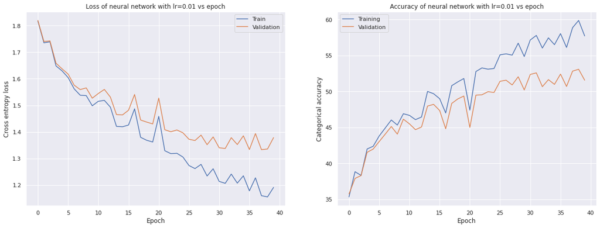

```python
### PLOT LEARNING CURVES FOR MLP ON 40 EPOCHS FOR LEARNING RATE 0.01 ###
fig = plt.figure(figsize=(20, 7))

sns.set()

fig.add_subplot(121)
plt.plot(L_1, label="Train")
plt.plot(L_val_1, label="Validation")
plt.xlabel("Epoch")
plt.ylabel("Cross entropy loss")
plt.legend()
plt.title("Loss of neural network with lr=0.01 vs epoch")

fig.add_subplot(122)
plt.plot(A_1, label="Training")
plt.plot(A_val_1, label="Validation")
plt.xlabel("Epoch")
plt.ylabel("Categorical accuracy")
plt.legend()
plt.title("Accuracy of neural network with lr=0.01 vs epoch")

plt.show()
```

```python
print("The best loss for learning rate 0.01 on 40 epochs is:", min(L_val_1))
print("The best validation accuracy for learning rate 0.01 on 40 epochs is:", max(A_val_1))
```

```
The best loss for learning rate 0.01 on 40 epochs is: 1.3332779713952798
The best validation accuracy for learning rate 0.01 on 40 epochs is: 53.08
```

**Convergence of the model**\ Clearly, this model with learning rate 0.01 on 40 epochs is quite interesting because it yields us a best validation accuracy of 53% which is already a bit more than 5 times better than randomness (because we have 10 categories).\ Regarding the convergence of the model, we can see that our model learns pretty fast as we can see a significant drop in the cross entropy loss over the training set, with some noise due to the stochastic aspect of our optimization (instead of computing the descent in the same direction at every epoch, we re-shuffle the data and find the best new direction: SGD). Regarding the validation set, the drop is a bit less significant but still quite satisfying. We can see that no overfitting is occurring on these 40 epochs, as the validation loss isn't going back up, however its drop is slowing down a lot which might mean that if we were to increase the number of epochs, it could overfit, we will explore this in 1.1.3.\ However one must note that we might want to try other parameters on the model, like increasing epochs or varying learning rate in order to see if we could improve the model accuracy.

# 1.1.2 Train MLP with different learning rates

Now let's try implement our MLP with different learning rates to see the impact on the loss and the accuracy:

LEARNING RATE = 0.0001

```python
### TRAIN MLP ON 40 EPOCHS WITH LEARNING RATE 0.0001 ###

# begin timing
import time
start = time.time()

# define model training parameters
epochs = 40
lr = 0.0001
batches = 390

L_2, L_val_2, A_2, A_val_2 = train_MLP(epochs, lr, batches, x_train, y_train)

# end timing
end = time.time()
time2 = int((end-start)//60)
print("The ellapsed time for 40 epochs with lr=0.0001 is:", time2)
```

```
epoch 1/40
[25%][50%][75%][100%]
The cross-entropy loss on the train set 2.2897608716922173
The cross-entropy loss on the validation set 2.289581183973729
The accuracy on the train set 12.814
The accuracy on the validation set 12.51
epoch 2/40
[25%][50%][75%][100%]
The cross-entropy loss on the train set 2.2659613322937857
The cross-entropy loss on the validation set 2.2659259305171076
The accuracy on the train set 15.72
The accuracy on the validation set 15.6
epoch 3/40
[25%][50%][75%][100%]
The cross-entropy loss on the train set 2.244822765913386
The cross-entropy loss on the validation set 2.2449170458917784
The accuracy on the train set 17.996
The accuracy on the validation set 17.97
epoch 4/40
[25%][50%][75%][100%]
The cross-entropy loss on the train set 2.224902084214757
The cross-entropy loss on the validation set 2.2251541365526295
The accuracy on the train set 20.08
The accuracy on the validation set 20.15
epoch 5/40
[25%][50%][75%][100%]
The cross-entropy loss on the train set 2.20578471002146
The cross-entropy loss on the validation set 2.2061707616279413
The accuracy on the train set 21.514
The accuracy on the validation set 21.74
epoch 6/40
[25%][50%][75%][100%]
The cross-entropy loss on the train set 2.187430708322737
The cross-entropy loss on the validation set 2.187927819430271
The accuracy on the train set 22.96
The accuracy on the validation set 23.31
epoch 7/40
[25%][50%][75%][100%]
The cross-entropy loss on the train set 2.169737159177325
The cross-entropy loss on the validation set 2.1703586043639365
```

[output cut: 186 more lines]

```
The accuracy on the train set 33.936
The accuracy on the validation set 33.92
epoch 39/40
[25%][50%][75%][100%]
The cross-entropy loss on the train set 1.8945616284154687
The cross-entropy loss on the validation set 1.8964015178107405
The accuracy on the train set 34.01
The accuracy on the validation set 34.0
epoch 40/40
[25%][50%][75%][100%]
The cross-entropy loss on the train set 1.8909432432528073
The cross-entropy loss on the validation set 1.8927806530123097
The accuracy on the train set 34.18
The accuracy on the validation set 34.17
The ellapsed time for 40 epochs with lr=0.0001 is: 21
```

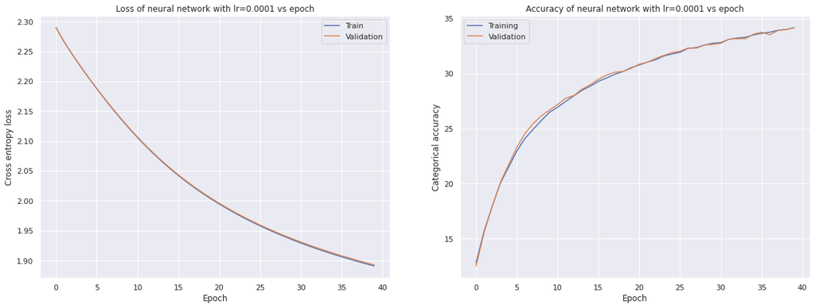

```python
### PLOT LEARNING CURVES FOR MLP ON 40 EPOCHS FOR LEARNING RATE 0.0001 ###
fig = plt.figure(figsize=(20, 7))

sns.set()

fig.add_subplot(121)
plt.plot(L_2, label="Train")
plt.plot(L_val_2, label="Validation")
plt.xlabel("Epoch")
plt.ylabel("Cross entropy loss")
plt.legend()
plt.title("Loss of neural network with lr=0.0001 vs epoch")

fig.add_subplot(122)
plt.plot(A_2, label="Training")
plt.plot(A_val_2, label="Validation")
plt.xlabel("Epoch")
plt.ylabel("Categorical accuracy")
plt.legend()
plt.title("Accuracy of neural network with lr=0.0001 vs epoch")

plt.show()
```

```python
print("The best loss for learning rate 0.0001 on 40 epochs is:", min(L_val_2))
print("The best validation accuracy for learning rate 0.0001 on 40 epochs is:", max(A_val_2))
```

```
The best loss for learning rate 0.0001 on 40 epochs is: 1.8927806530123097
The best validation accuracy for learning rate 0.0001 on 40 epochs is: 34.17
```

**Discussion of convergence and performance**

In this case, we can see that the train and validation loss are following exactly the same path. It shows a clear sign of underfitting. Similarly for the train and validation accuracy, which gets to a max of 35%. We can see that this model isn't converging fast enough, the learning rate is most probably to slow. Here we don't see the noisiness expected from SGD because the increment is so small (0.0001) that we could only see it by zooming in. Clearly the loss curve is still descending and if we were to increase the number of epochs, we would probably be able to see that, but it will increase the overall training time, which is a downside as we are looking for something both accurate and rapid: efficiency.

LEARNING RATE = 0.1

```python
### TRAIN MLP ON 40 EPOCHS WITH LEARNING RATE 0.1 ###

# begin timing
import time
start = time.time()

# define model training parameters
epochs = 40
lr = 0.1
batches = 390

L_3, L_val_3, A_3, A_val_3 = train_MLP(epochs, lr, batches, x_train, y_train)

# end timing
end = time.time()
time3 = int((end-start)//60)
print("The ellapsed time for 40 epochs with lr=0.1 is:", time3)
```

```
epoch 1/40
[25%][50%][75%][100%]
The cross-entropy loss on the train set 1.8601089295150681
The cross-entropy loss on the validation set 1.865940829731978
The accuracy on the train set 32.602
The accuracy on the validation set 32.77
epoch 2/40
[25%][50%][75%][100%]
The cross-entropy loss on the train set 1.6824349075407983
The cross-entropy loss on the validation set 1.685877713619952
The accuracy on the train set 40.246
The accuracy on the validation set 40.51
epoch 3/40
[25%][50%][75%][100%]
The cross-entropy loss on the train set 1.718928979381813
The cross-entropy loss on the validation set 1.7326459959578522
The accuracy on the train set 37.596
The accuracy on the validation set 37.56
epoch 4/40
[25%][50%][75%][100%]
The cross-entropy loss on the train set 1.6063371672201814
The cross-entropy loss on the validation set 1.634068699378362
The accuracy on the train set 41.496
The accuracy on the validation set 40.58
epoch 5/40
[25%][50%][75%][100%]
The cross-entropy loss on the train set 1.6233114021624415
The cross-entropy loss on the validation set 1.6532619744365937
The accuracy on the train set 42.11
The accuracy on the validation set 40.84
epoch 6/40
[25%][50%][75%][100%]
The cross-entropy loss on the train set 1.4956137920716557
The cross-entropy loss on the validation set 1.5397214413515317
The accuracy on the train set 45.906
The accuracy on the validation set 44.38
epoch 7/40
[25%][50%][75%][100%]
The cross-entropy loss on the train set 1.4408197015719404
The cross-entropy loss on the validation set 1.4937751681767175
```

[output cut: 186 more lines]

```
The accuracy on the train set 79.342
The accuracy on the validation set 49.65
epoch 39/40
[25%][50%][75%][100%]
The cross-entropy loss on the train set 0.5039263669435148
The cross-entropy loss on the validation set 1.7748984811394446
The accuracy on the train set 82.476
The accuracy on the validation set 51.27
epoch 40/40
[25%][50%][75%][100%]
The cross-entropy loss on the train set 0.4444687787727113
The cross-entropy loss on the validation set 1.805436683863818
The accuracy on the train set 84.724
The accuracy on the validation set 51.35
The ellapsed time for 40 epochs with lr=0.1 is: 23
```

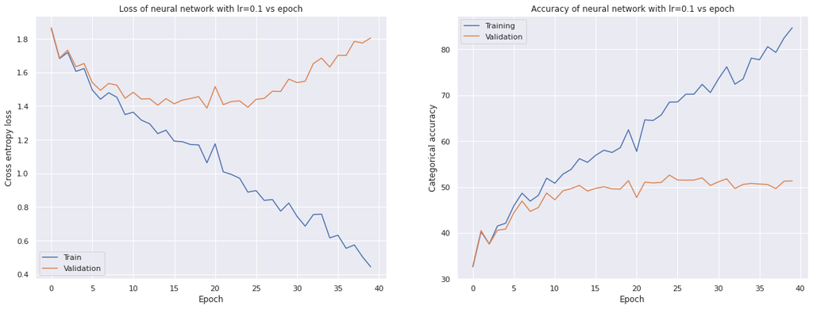

```python
### PLOT LEARNING CURVES FOR MLP ON 40 EPOCHS FOR LEARNING RATE 0.1 ###
fig = plt.figure(figsize=(20, 7))

sns.set()

fig.add_subplot(121)
plt.plot(L_3, label="Train")
plt.plot(L_val_3, label="Validation")
plt.xlabel("Epoch")
plt.ylabel("Cross entropy loss")
plt.legend()
plt.title("Loss of neural network with lr=0.1 vs epoch")

fig.add_subplot(122)
plt.plot(A_3, label="Training")
plt.plot(A_val_3, label="Validation")
plt.xlabel("Epoch")
plt.ylabel("Categorical accuracy")
plt.legend()
plt.title("Accuracy of neural network with lr=0.1 vs epoch")

plt.show()
```

```python
print("The best loss for learning rate 0.1 on 40 epochs is:", min(L_val_3))
print("The best validation accuracy for learning rate 0.1 on 40 epochs is:", max(A_val_3))
```

```
The best loss for learning rate 0.1 on 40 epochs is: 1.3878909137374766
The best validation accuracy for learning rate 0.1 on 40 epochs is: 52.6
```

**Discussion of convergence and performance**

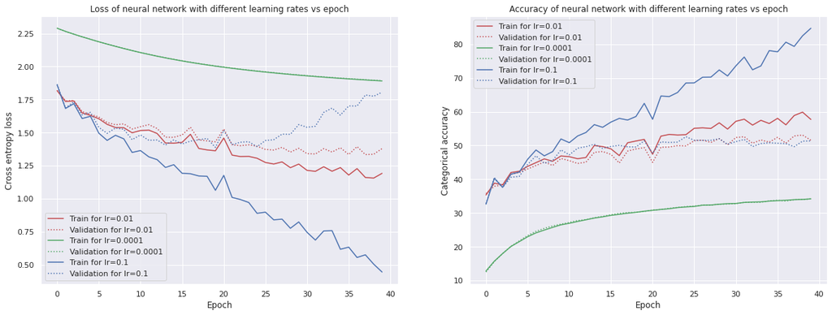

```python
### PLOT LEARNING CURVES FOR MLP ON 40 EPOCHS FOR LEARNING RATE 0.1, 0.01 & 0.0001 ###
fig = plt.figure(figsize=(20, 7))

sns.set()

fig.add_subplot(121)
plt.plot(L_1, color='r', label="Train for lr=0.01")
plt.plot(L_val_1, color='r', linestyle='dotted', label="Validation for lr=0.01")
plt.plot(L_2, color='g', label="Train for lr=0.0001")
plt.plot(L_val_2, color='g', linestyle='dotted', label="Validation for lr=0.0001")
plt.plot(L_3, color='b', label="Train for lr=0.1")
plt.plot(L_val_3, color='b', linestyle='dotted', label="Validation for lr=0.1")
plt.xlabel("Epoch")
plt.ylabel("Cross entropy loss")
plt.legend()
plt.title("Loss of neural network with different learning rates vs epoch")

fig.add_subplot(122)
plt.plot(A_1, color='r', label="Train for lr=0.01")
plt.plot(A_val_1, color='r', linestyle='dotted', label="Validation for lr=0.01")
plt.plot(A_2, color='g', label="Train for lr=0.0001")
plt.plot(A_val_2, color='g', linestyle='dotted', label="Validation for lr=0.0001")
plt.plot(A_3, color='b', label="Train for lr=0.1")
plt.plot(A_val_3, color='b', linestyle='dotted', label="Validation for lr=0.1")
plt.xlabel("Epoch")
plt.ylabel("Categorical accuracy")
plt.legend()
plt.title("Accuracy of neural network with different learning rates vs epoch")

plt.show()
```

**Discussion of the three learning rates**

- Learning rate=0.1

  *accuracy:* training accuracy is the best out of the three (around 83%) however as said above, strong overfitting which makes the val accuracy around 50% --> discard model because loss is going up intensely
- Learning rate=0.01

  *loss:* decreasing curve for both validation and training. Validation is starting to slow down, so any idea of increasing the number of epochs to see if accuracy is increased could be explore, however risk of overfitting

  *accuracy:* validation accuracy goes beyond 50%, which is quite satisfying compared to the other models --> keep model
- Learning rate=0.0001

  *loss:* both training and validation loss are going down very slowly which indicates that the model has a learning rate that is too slow: underfitting

  *accuracy:* similarly, accuracy is going up but not fast enough due to the slowness of the model --> increase learning rate or extend number of epochs

# 1.1.3 Train MLP on 80 epochs with learning rate 0.01

```python
### TRAIN MLP ON 80 EPOCHS WITH LEARNING RATE 0.01 ###

# begin timing
import time
start = time.time()

# define model training parameters
epochs = 80
lr = 0.01
batches = 390

L_4, L_val_4, A_4, A_val_4 = train_MLP(epochs, lr, batches, x_train, y_train)

# end timing
end = time.time()
time4 = int((end-start)//60)
print("The ellapsed time for 80 epochs with lr=0.01 is:", time4)
```

```
epoch 1/80
[25%][50%][75%][100%]
The cross-entropy loss on the train set 1.8253066864581189
The cross-entropy loss on the validation set 1.83001506925519
The accuracy on the train set 34.81
The accuracy on the validation set 34.38
epoch 2/80
[25%][50%][75%][100%]
The cross-entropy loss on the train set 1.8179892455682882
The cross-entropy loss on the validation set 1.821426230284612
The accuracy on the train set 34.512
The accuracy on the validation set 34.52
epoch 3/80
[25%][50%][75%][100%]
The cross-entropy loss on the train set 1.7383465089244101
The cross-entropy loss on the validation set 1.749193166691496
The accuracy on the train set 38.16
The accuracy on the validation set 38.41
epoch 4/80
[25%][50%][75%][100%]
The cross-entropy loss on the train set 1.8170896557361615
The cross-entropy loss on the validation set 1.8356792284603816
The accuracy on the train set 35.566
The accuracy on the validation set 35.17
epoch 5/80
[25%][50%][75%][100%]
The cross-entropy loss on the train set 1.63250670451363
The cross-entropy loss on the validation set 1.6462553675803087
The accuracy on the train set 42.25
The accuracy on the validation set 42.16
epoch 6/80
[25%][50%][75%][100%]
The cross-entropy loss on the train set 1.60876373724648
The cross-entropy loss on the validation set 1.6241327356577813
The accuracy on the train set 43.808
The accuracy on the validation set 43.59
epoch 7/80
[25%][50%][75%][100%]
The cross-entropy loss on the train set 1.5711798719996761
The cross-entropy loss on the validation set 1.5908815499359714
```

[output cut: 426 more lines]

```
The accuracy on the train set 72.886
The accuracy on the validation set 54.29
epoch 79/80
[25%][50%][75%][100%]
The cross-entropy loss on the train set 0.77757216274712
The cross-entropy loss on the validation set 1.3787554045803398
The accuracy on the train set 72.748
The accuracy on the validation set 54.07
epoch 80/80
[25%][50%][75%][100%]
The cross-entropy loss on the train set 0.7491908010051735
The cross-entropy loss on the validation set 1.3625782637019892
The accuracy on the train set 74.016
The accuracy on the validation set 54.99
The ellapsed time for 80 epochs with lr=0.01 is: 44
```

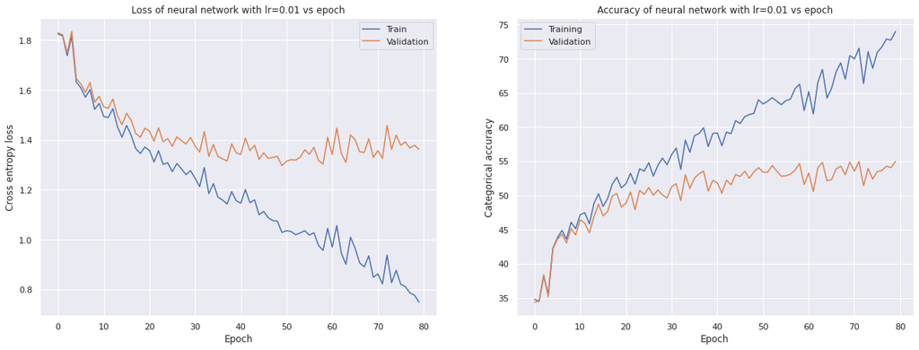

```python
### PLOT LEARNING CURVES FOR MLP ON 80 EPOCHS FOR LEARNING RATE 0.01 ###
fig = plt.figure(figsize=(20, 7))

sns.set()

fig.add_subplot(121)
plt.plot(L_4, label="Train")
plt.plot(L_val_4, label="Validation")
plt.xlabel("Epoch")
plt.ylabel("Cross entropy loss")
plt.legend()
plt.title("Loss of neural network with lr=0.01 vs epoch")

fig.add_subplot(122)
plt.plot(A_4, label="Training")
plt.plot(A_val_4, label="Validation")
plt.xlabel("Epoch")
plt.ylabel("Categorical accuracy")
plt.legend()
plt.title("Accuracy of neural network with lr=0.01 vs epoch")

plt.show()
```

```python
print("The best loss for learning rate 0.01 on 80 epochs is:", min(L_val_4))
print("The best validation accuracy for learning rate 0.01 on 80 epochs is:", max(A_val_4))
```

```
The best loss for learning rate 0.01 on 80 epochs is: 1.2968034700832374
The best validation accuracy for learning rate 0.01 on 80 epochs is: 54.99
```

**Comment on accuracy and convergence**

As mentioned in 1.1.1, the learning rate=0.01 presents some nice resulsts over 40 epochs with a still decreasing loss, so we wanted to explore what an increase in number of epochs would do to our model, bewaring of overfitting. What was supposed to happen, happened: there is clear overfitting going on after epoch 50, where the validation loss increases, which also makes our validation accuracy stagnate around the same value that we get from epoch 50. Hence we could re implement a training with 50 epochs for example for two reasons:

1. we saw earlier that this was the best learning rate out of the three tested.
2. beyond 50 epochs, our model is overfitting

Now, let's do a table to summarize the main results from our models implementation:

```python
Learning_Rate = [0.01, 0.0001, 0.1, 0.01]
Number_of_Epochs = [40, 40, 40, 80]
Loss_tot_train = [min(L_1), min(L_2), min(L_3), min(L_4)]
Loss_tot_test = [min(L_val_1), min(L_val_2), min(L_val_3), min(L_val_4)]
Acc_tot_train = [max(A_1), max(A_2), max(A_3), max(A_4)]
Acc_tot_test = [max(A_val_1), max(A_val_2), max(A_val_3), max(A_val_4)]
Time = [time1, time2, time3, time4]

comparison = np.array([Learning_Rate, Number_of_Epochs, Loss_tot_train, Loss_tot_test, Acc_tot_train, Acc_tot_test, Time]).T
comparison = pd.DataFrame(comparison)
comparison.columns = ['Learning Rate','Number of Epochs', 'Training loss', 'Test loss', 'Training accuracy', 'Validation accuracy', 'Timing ellapsed']
comparison.head()
```

|  | Learning Rate | Number of Epochs | Training loss | Test loss | Training accuracy | Validation accuracy | Timing ellapsed |
| --- | --- | --- | --- | --- | --- | --- | --- |
| 0 | 0.0100 | 40.0 | 1.155633 | 1.333278 | 59.870 | 53.08 | 22.0 |
| 1 | 0.0001 | 40.0 | 1.890943 | 1.892781 | 34.180 | 34.17 | 21.0 |
| 2 | 0.1000 | 40.0 | 0.444469 | 1.387891 | 84.724 | 52.60 | 23.0 |
| 3 | 0.0100 | 80.0 | 0.749191 | 1.296803 | 74.016 | 54.99 | 44.0 |

**Explanation of results and comparison of models**

*Learning Rate*

Clearly we can see that the setting of the learning rate should be a balance between our model learning not too fast, otherwise it skips important features (lr=0.1), but not too slow either because otherwise it takes to long to converge (lr=0.0001). This is the whole challenge of NN, to be able to balance the hyperparamaters to combine accuracy and rapidity in order to make an efficient model.\ In our example, we see that the best learning rate that we have tested is 0.01 based on the validation accuracy that it yields.

*Number of epochs*

Regarding the number of epochs, we can see that it's a similar idea as learning rate on the aspect that it's a balance because if too many, you risk overfitting like in the 4th model we tried (lr=0.01 on 80 epochs) and if too few you don't have time to improve you accuracy.

*Cross-entropy loss*

The cross entropy loss is minimal on the 80 epochs model but otherwise on the 40 epochs with learning rate 0.01, and from our comments beforehand, we have seen that it is a satisfying model.

*Accuracy*

The best validation accuracy that we get is for the learning rate 0.01 with 53% on 40 epochs and almost 55% on 80 epochs. However, as explained before, we've seen that 80 epochs presents strong signs of overfitting, and also for a twice as long training time, you only get an increase of 1% in accuracy. It isn't a good trade-off for complexity, timing and accuracy. Hence the first one we tried is the best compared to its peers.

*Timing*

Clearly, the model with twice the number of epochs takes twice the time because it's twice as long, otherwise all models with same number of epochs take all the same time to train. What would be interesting is to compare it to the training time from the tensorflow CNN as we will do in 1.2.4.

**Conclusion**

From these different models implemented, we have that the model with learning rate 0.01 trained on 40 epochs is the best relative to the other ones in terms of accuracy, loss and training time, and it isn't showing signs of uderfitting not overfitting.

# 1.2 Convolutional Neural Network (CNN)

In this task we are going to implement a Convolutional Neural Network according to the following architecture:

- 4 hidden layers (activated by ReLu):
  - 3 convolutional layers with 3x3 feature map and 2x2 max pooling layers in between them
  - 1 fully connected layer with 64 neurons
- 1 output layer (activated by softmax):
  - 10 ouputted neurons

We are using stochastic gradient descent (SGD) to fix the optimization with a cross-entropy loss function. Additionally, we are dividing our data into batches of 128 points, like in part 1.1, which gives us $\frac{50000}{128}=391$ batches to train on.

Note that for this task, we are activating GPU in the google colab as it makes our epochs run 25 times faster (from 50s to 2s) because tensorflow is optimised for Colab.

## 1.2.0 Load data

First and foremost, let's load the necessary libraries for this task, load the data and check the shape

```python
### LOAD NECESSARY LIBRARIES ###

import tensorflow as tf
import numpy as np
import pandas as pd
import seaborn as sns
import matplotlib.pyplot as plt
from tensorflow.keras import datasets, layers, models
```

```python
### LOAD DATA FUNCTION FROM FELIX ###

def load_data():
    (x_train, y_train), (x_val, y_val) = tf.keras.datasets.cifar10.load_data()
    x_train = x_train.astype('float32') / 255
    x_val = x_val.astype('float32') / 255

    #convert labels to categorical samples
    y_train = tf.keras.utils.to_categorical(y_train, num_classes=10)
    y_val = tf.keras.utils.to_categorical(y_val, num_classes=10)
    return ((x_train, y_train), (x_val, y_val))

(x_train, y_train), (x_val, y_val) = load_data()
```

```python
### SHUFFLE DATA ###
shuffle = np.random.permutation(range(x_train.shape[0]))

x_train = x_train[shuffle]
y_train = y_train[shuffle]
```

```python
### CHECK SHAPE OF DATA ###
print(x_train.shape)
print(y_train.shape)
print(x_val.shape)
print(y_val.shape)
```

```
(50000, 32, 32, 3)
(50000, 10)
(10000, 32, 32, 3)
(10000, 10)
```

## 1.2.1 Implement CNN

Now that our data is loaded, we can implement our first CNN with a learning rate of 0.1 for 40 epochs as follows:

```python
### MODEL 1 WITH LR=0.1 ON 40 EPOCHS ###

from tensorflow.keras.models import Sequential
from tensorflow.keras.layers import Conv2D, MaxPooling2D, Flatten, Dense
from tensorflow import keras

def get_model(): # function as from CT
    model = Sequential([
        Conv2D(32, (3, 3), activation='relu', input_shape=(32, 32, 3)), # convolutional layer
        MaxPooling2D((2, 2)), # max pooling layer
        Conv2D(64, (3, 3), activation='relu'), # convolutional layer
        MaxPooling2D((2, 2)), # max pooling layer
        Conv2D(64, (3, 3), activation='relu'), # convolutional layer
        Flatten(),
        Dense(64, activation='relu'), # fully connected layer with 64 neurons
        Dense(10, activation='softmax') # output layer with 10 neurons
    ])

    opt = keras.optimizers.SGD(learning_rate=0.1) # select Stochastic Gradient Descent as optimisation method with 0.01 learning rate
    model.compile(loss='categorical_crossentropy', optimizer=opt, metrics=['accuracy']) # compile model with cross-entropy loss
    return model
```

```python
### GET MODEL 1 SUMMARY ###
model = get_model()
model.summary()
```

```
Model: "sequential"
_________________________________________________________________
Layer (type)                 Output Shape              Param #
=================================================================
conv2d (Conv2D)              (None, 30, 30, 32)        896
_________________________________________________________________
max_pooling2d (MaxPooling2D) (None, 15, 15, 32)        0
_________________________________________________________________
conv2d_1 (Conv2D)            (None, 13, 13, 64)        18496
_________________________________________________________________
max_pooling2d_1 (MaxPooling2 (None, 6, 6, 64)          0
_________________________________________________________________
conv2d_2 (Conv2D)            (None, 4, 4, 64)          36928
_________________________________________________________________
flatten (Flatten)            (None, 1024)              0
_________________________________________________________________
dense (Dense)                (None, 64)                65600
_________________________________________________________________
dense_1 (Dense)              (None, 10)                650
=================================================================
Total params: 122,570
Trainable params: 122,570
Non-trainable params: 0
_________________________________________________________________
```

```python
### FIT AND TIME MODEL ###
import time
start = time.time()

history = model.fit(x_train, y_train, validation_data=(x_val, y_val), epochs=40, batch_size=128) # turn on GPU

end = time.time()

time21 = int((end - start)/60)
print("The total running time for model with 0.1 lr on 40 epochs is:", time21)
```

```
The total running time for model with 0.1 lr on 40 epochs is: 1
```

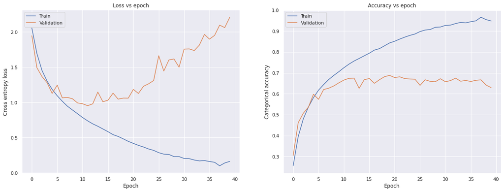

```python
### PLOT LEARNING CURVES FOR MODEL 1  ###

fig = plt.figure(figsize=(20, 7))

sns.set()

fig.add_subplot(121)
plt.plot(history.history['loss'], label='Train')
plt.plot(history.history['val_loss'], label='Validation')
plt.xlabel("Epoch")
plt.ylabel("Cross entropy loss")
plt.legend()
plt.title("Loss vs epoch")

fig.add_subplot(122)
plt.plot(history.history['accuracy'], label='Train')
plt.plot(history.history['val_accuracy'], label='Validation')
plt.xlabel("Epoch")
plt.ylabel("Categorical accuracy")
plt.legend()
plt.title("Accuracy vs epoch")

plt.show()
```

```python
print("The best loss for learning rate 0.1 on 40 epochs is:", min(history.history['val_loss']))
print("The best validation accuracy for learning rate 0.1 on 40 epochs is:", max(history.history['val_accuracy']))
```

```
The best loss for learning rate 0.1 on 40 epochs is: 0.9523820281028748
The best validation accuracy for learning rate 0.1 on 40 epochs is: 0.6880000233650208
```

Now, let's discuss the convergence of the model and any possible signatures of underfitting or overfitting.

**Convergence of the model**

Our validation loss seems to be increasing after epoch 15, which is a sign of overfitting and indeed we can see that the corresponding validation accuracy doesn't increase after epoch 15. It stagnates around 69% of accuracy. However, this is already so much better than the MLP learning values. In terms of noisiness, as for both methods we have used SGD optimization, we can see that the curves are quite noisy but that's just from the randomness aspect of SGD.

## 1.2.2 Implement L2 regularisation

Now we incorporate an L2 regularisation with a coefficient of $5.10^{-3}$ in each convolutional layer.

```python
### MODEL 2 WITH LR=0.1 ON 40 EPOCHS AND L2 REGULARISATION IN EACH CONVOLUTIONAL LAYER ###

from tensorflow.keras.models import Sequential
from tensorflow.keras.layers import Conv2D, MaxPooling2D, Flatten, Dense
from tensorflow.keras.regularizers import l2
from tensorflow import keras

def get_model2():
  model = Sequential([
                    Conv2D(32, (3,3), activation='relu', kernel_regularizer=l2(5e-03), input_shape=(32,32,3)),
                    MaxPooling2D((2,2)),
                    Conv2D(64, (3,3), activation='relu', kernel_regularizer=l2(5e-03)),
                    MaxPooling2D((2,2)),
                    Conv2D(64, (3,3), activation='relu', kernel_regularizer=l2(5e-03)),
                    Flatten(),
                    Dense(64, activation='relu'),
                    Dense(10, activation='softmax')
                    ])
  opt = keras.optimizers.SGD(learning_rate=0.1)
  model.compile(loss='categorical_crossentropy', optimizer=opt, metrics=['accuracy'])
  return model
```

```python
### GET MODEL 1 SUMMARY ###
model2 = get_model2()
model2.summary()
```

```
Model: "sequential_1"
_________________________________________________________________
Layer (type)                 Output Shape              Param #
=================================================================
conv2d_3 (Conv2D)            (None, 30, 30, 32)        896
_________________________________________________________________
max_pooling2d_2 (MaxPooling2 (None, 15, 15, 32)        0
_________________________________________________________________
conv2d_4 (Conv2D)            (None, 13, 13, 64)        18496
_________________________________________________________________
max_pooling2d_3 (MaxPooling2 (None, 6, 6, 64)          0
_________________________________________________________________
conv2d_5 (Conv2D)            (None, 4, 4, 64)          36928
_________________________________________________________________
flatten_1 (Flatten)          (None, 1024)              0
_________________________________________________________________
dense_2 (Dense)              (None, 64)                65600
_________________________________________________________________
dense_3 (Dense)              (None, 10)                650
=================================================================
Total params: 122,570
Trainable params: 122,570
Non-trainable params: 0
_________________________________________________________________
```

```python
### FIT AND TIME MODEL ###
import time
start = time.time()

history2 = model2.fit(x_train, y_train, validation_data=(x_val, y_val), epochs=40, batch_size=128) # turn on GPU

end = time.time()

time22 = int((end - start)/60)
print("The ellapsed time for 40 epochs with lr 0.1 and L2 regularisation is:", time22)
```

```
The ellapsed time for 40 epochs with lr 0.1 and L2 regularisation is: 1
```

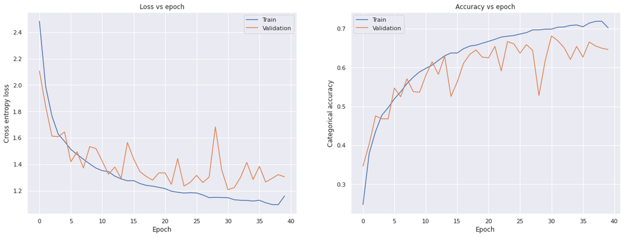

```python
### PLOT LEARNING CURVES FOR MODEL 2  ###

fig = plt.figure(figsize=(20, 7))

sns.set()

fig.add_subplot(121)
plt.plot(history2.history['loss'], label='Train')
plt.plot(history2.history['val_loss'], label='Validation')
plt.xlabel("Epoch")
plt.ylabel("Cross entropy loss")
plt.legend()
plt.title("Loss vs epoch")

fig.add_subplot(122)
plt.plot(history2.history['accuracy'], label='Train')
plt.plot(history2.history['val_accuracy'], label='Validation')
plt.xlabel("Epoch")
plt.ylabel("Categorical accuracy")
plt.legend()
plt.title("Accuracy vs epoch")

plt.show()
```

```python
print("The best loss for learning rate 0.1 on 40 epochs with L2 regularisation is:", min(history2.history['val_loss']))
print("The best validation accuracy for learning rate 0.1 on 40 epochs with L2 regularisation is:", max(history2.history['val_accuracy']))
```

```
The best loss for learning rate 0.1 on 40 epochs with L2 regularisation is: 1.2079341411590576
The best validation accuracy for learning rate 0.1 on 40 epochs with L2 regularisation is: 0.6812000274658203
```

Now, let's compare the loss and accuracy of this model 2 compared to model 1:

Now we can explain how the regularisation affects the training procedure: [5]

Regularisation is a method that is widely used in order to avoid overfitting and increase our model interpretability. Essentially, it reduces the variance of the model, without substantial increase in its bias. It encourages sparsity in the weights; it discourages the weights from growing too large, which restricts the capacity of the network. In our case, simply we manage to not have overfitting while achieving a good validation acccuracy.

Mathematically L2 regularisation is defined as: $L(\textbf{w},\alpha)= L_0(\textbf{w}) + \alpha_2 \sum_i w_i^2$, where $L_0$ is the unconstrained loss (here cross entropy) and $\alpha_2$ is the regularisation parameter, which is actually a hyperparameter that we have set from the exercise to be $5*10^{-3}$.

## 1.2.3 Implement Dropout and another regularization: Stopping criterion

In this section, we will try implementing a Dropout with rate 0.5 on the same initial model and then a stopping criteron on the same initial model. This will allows us to compare them all afterwards.

**DROPOUT**

```python
### MODEL 3 WITH LR=0.1 ON 40 EPOCHS, A DROPOUT RATE OF 0.5 BETWEEN CONVOLUTIONAL LAYER ###

from tensorflow.keras.models import Sequential
from tensorflow.keras.layers import Conv2D, MaxPooling2D, Flatten, Dense, Dropout
from tensorflow.keras.regularizers import l2
from tensorflow import keras

def get_model3():
  rate = 0.5
  model = Sequential([
                      Conv2D(32, (3,3), activation='relu', input_shape=(32,32,3)),
                      MaxPooling2D((2,2)),
                      Dropout(rate),
                      Conv2D(64, (3,3), activation='relu'),
                      MaxPooling2D((2,2)),
                      Dropout(rate),
                      Conv2D(64, (3,3), activation='relu'),
                      Flatten(),
                      Dense(64, activation='relu'),
                      Dense(10, activation='softmax')
                    ])

  opt = keras.optimizers.SGD(learning_rate=0.1)
  model.compile(loss='categorical_crossentropy', optimizer=opt, metrics=['accuracy'])
  return model
```

```python
### GET MODEL 3 SUMMARY ###
model3 = get_model3()
model3.summary()
```

```
Model: "sequential_2"
_________________________________________________________________
Layer (type)                 Output Shape              Param #
=================================================================
conv2d_6 (Conv2D)            (None, 30, 30, 32)        896
_________________________________________________________________
max_pooling2d_4 (MaxPooling2 (None, 15, 15, 32)        0
_________________________________________________________________
dropout (Dropout)            (None, 15, 15, 32)        0
_________________________________________________________________
conv2d_7 (Conv2D)            (None, 13, 13, 64)        18496
_________________________________________________________________
max_pooling2d_5 (MaxPooling2 (None, 6, 6, 64)          0
_________________________________________________________________
dropout_1 (Dropout)          (None, 6, 6, 64)          0
_________________________________________________________________
conv2d_8 (Conv2D)            (None, 4, 4, 64)          36928
_________________________________________________________________
flatten_2 (Flatten)          (None, 1024)              0
_________________________________________________________________
dense_4 (Dense)              (None, 64)                65600
_________________________________________________________________
dense_5 (Dense)              (None, 10)                650
=================================================================
Total params: 122,570
Trainable params: 122,570
Non-trainable params: 0
_________________________________________________________________
```

```python
### FIT MODEL 3 ###
import time
start = time.time()

history3 = model3.fit(x_train, y_train, validation_data=(x_val, y_val), epochs=40, batch_size=128) # turn on GPU

end = time.time()

time23 = int((end - start)/60)
print("The ellapsed time for 40 epochs with lr 0.1 and Dropout:", time23)
```

```
The ellapsed time for 40 epochs with lr 0.1 and Dropout: 1
```

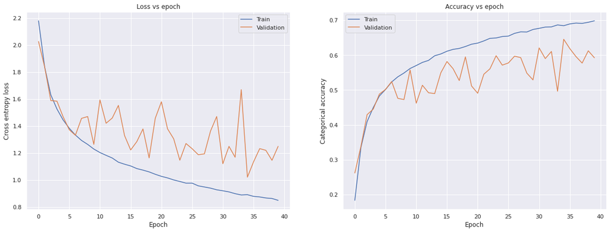

```python
### PLOT LEARNING CURVES FOR MODEL 3  ###

fig = plt.figure(figsize=(20, 7))

sns.set()

fig.add_subplot(121)
plt.plot(history3.history['loss'], label='Train')
plt.plot(history3.history['val_loss'], label='Validation')
plt.xlabel("Epoch")
plt.ylabel("Cross entropy loss")
plt.legend()
plt.title("Loss vs epoch")

fig.add_subplot(122)
plt.plot(history3.history['accuracy'], label='Train')
plt.plot(history3.history['val_accuracy'], label='Validation')
plt.xlabel("Epoch")
plt.ylabel("Categorical accuracy")
plt.legend()
plt.title("Accuracy vs epoch")

plt.show()
```

```python
print("The best loss for learning rate 0.1 on 40 epochs with dropout is:", min(history3.history['val_loss']))
print("The best validation accuracy for learning rate 0.1 on 40 epochs with dropout is:", max(history3.history['val_accuracy']))
```

```
The best loss for learning rate 0.1 on 40 epochs with dropout is: 1.0212005376815796
The best validation accuracy for learning rate 0.1 on 40 epochs with dropout is: 0.6453999876976013
```

**Comment**

The Dropout technique essentially drops out randomly neurons in the network. This has a similar effect as the regularisation. It also prevents neurons from co-adapting too much to each other. We can see that results in terms of loss and accuracy are similar to the one with L2 reg, although a bit smaller in accuracy but better loss, this model doesn't present any sign of overfitting. Here our hyperparameter is the dropout rate, which is set by the exercise to 0.5.

**EARLY STOPPPING**

```python
### MODEL 4 WITH LR=0.1 ON 40 EPOCHS AND AN EARLY STOPPING REGULARISATION###

from tensorflow.keras.models import Sequential
from tensorflow.keras.layers import Conv2D, MaxPooling2D, Flatten, Dense, Dropout
from tensorflow.keras.callbacks import EarlyStopping

def get_model4():
  model = Sequential([
                      Conv2D(32, (3,3), activation='relu', input_shape=(32,32,3)),
                      MaxPooling2D((2,2)),
                      Conv2D(64, (3,3), activation='relu'),
                      MaxPooling2D((2,2)),
                      Conv2D(64, (3,3), activation='relu'),
                      Flatten(),
                      Dense(64, activation='relu'),
                      Dense(10, activation='softmax')
                    ])

  opt = keras.optimizers.SGD(learning_rate=0.1)
  model.compile(loss='categorical_crossentropy', optimizer=opt, metrics=['accuracy'])
  return model
```

```python
### GET MODEL 4 SUMMARY ###
model4 = get_model4()
model4.summary()
```

```
Model: "sequential_3"
_________________________________________________________________
Layer (type)                 Output Shape              Param #
=================================================================
conv2d_9 (Conv2D)            (None, 30, 30, 32)        896
_________________________________________________________________
max_pooling2d_6 (MaxPooling2 (None, 15, 15, 32)        0
_________________________________________________________________
conv2d_10 (Conv2D)           (None, 13, 13, 64)        18496
_________________________________________________________________
max_pooling2d_7 (MaxPooling2 (None, 6, 6, 64)          0
_________________________________________________________________
conv2d_11 (Conv2D)           (None, 4, 4, 64)          36928
_________________________________________________________________
flatten_3 (Flatten)          (None, 1024)              0
_________________________________________________________________
dense_6 (Dense)              (None, 64)                65600
_________________________________________________________________
dense_7 (Dense)              (None, 10)                650
=================================================================
Total params: 122,570
Trainable params: 122,570
Non-trainable params: 0
_________________________________________________________________
```

```python
### FIT MODEL 4 ###
import time
start = time.time()

early_stopping = EarlyStopping(patience=2, monitor='val_accuracy')
history4 = model4.fit(x_train, y_train, validation_data=(x_val, y_val), epochs=40, batch_size=128, callbacks=[early_stopping])

end = time.time()

time24 = int((end - start)/60)
print("The ellapsed time for 40 epochs with lr 0.1 and stopping criterion is:", time24)
```

```
The ellapsed time for 40 epochs with lr 0.1 and stopping criterion is: 0
```

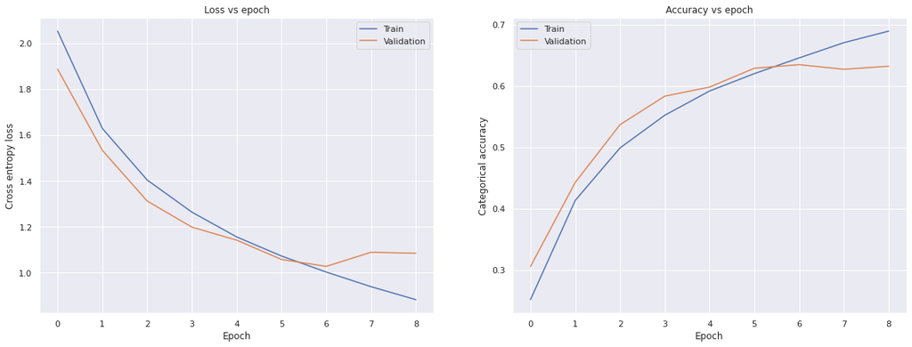

```python
### PLOT LEARNING CURVES FOR MODEL 4  ###

fig = plt.figure(figsize=(20, 7))

sns.set()

fig.add_subplot(121)
plt.plot(history4.history['loss'], label='Train')
plt.plot(history4.history['val_loss'], label='Validation')
plt.xlabel("Epoch")
plt.ylabel("Cross entropy loss")
plt.legend()
plt.title("Loss vs epoch")

fig.add_subplot(122)
plt.plot(history4.history['accuracy'], label='Train')
plt.plot(history4.history['val_accuracy'], label='Validation')
plt.xlabel("Epoch")
plt.ylabel("Categorical accuracy")
plt.legend()
plt.title("Accuracy vs epoch")

plt.show()
```

```python
print("The best loss for learning rate 0.1 on 40 epochs with early stopping criterion is:", min(history4.history['val_loss']))
print("The best validation accuracy for learning rate 0.1 on 40 epochs with early stopping criterion is:", max(history4.history['val_accuracy']))
```

```
The best loss for learning rate 0.1 on 40 epochs with early stopping criterion is: 1.027906894683838
The best validation accuracy for learning rate 0.1 on 40 epochs with early stopping criterion is: 0.6345999836921692
```

**Comment**

Now we can compare the results of our stopping criterion to the L2 regularisation, the Dropout and the standard model as follows:

```python
### VALUES FOR CNN ###

Learning_Rate2 = [0.1, 0.1, 0.1, 0.1]
Number_of_Epochs2 = [40, 40, 40, 40]
Loss_tot_train2 = [min(history.history['loss']), min(history2.history['loss']), min(history3.history['loss']), min(history4.history['loss'])]
Loss_tot_test2 = [min(history.history['val_loss']), min(history2.history['val_loss']), min(history3.history['val_loss']), min(history4.history['val_loss'])]
Acc_tot_train2 = [max(history.history['accuracy']), max(history2.history['accuracy']), max(history3.history['accuracy']), max(history4.history['accuracy'])]
Acc_tot_test2 = [max(history.history['val_accuracy']), max(history2.history['val_accuracy']), max(history3.history['val_accuracy']), max(history4.history['val_accuracy'])]
Regularisation = ['none', 'L2=5*10^-3', 'dropout rate=0.5', 'early stopping:patience=15']
run_epoch2 = [time21, time22, time23, time24]


comparison2 = np.array([Learning_Rate2, Number_of_Epochs2, Regularisation, Loss_tot_train2, Loss_tot_test2, Acc_tot_train2, Acc_tot_test2, run_epoch2]).T
comparison2 = pd.DataFrame(comparison2)
comparison2.columns = ['Learning Rate','Number of Epochs', 'Regularisation','Training loss', 'Test loss', 'Training accuracy', 'Validation accuracy', 'Timing ellapsed']
comparison2.head()
```

[output not shown]

## 1.2.4 Compare results from MLP and CNN

```python
### VALUES FOR MLP ###

Learning_Rate = [0.01, 0.0001, 0.1, 0.01]
Number_of_Epochs = [40, 40, 40, 80]
Loss_tot_train = [min(L_1), min(L_2), min(L_3), min(L_4)]
Loss_tot_test = [min(L_val_1), min(L_val_2), min(L_val_3), min(L_val_4)]
Acc_tot_train = [max(A_1), max(A_2), max(A_3), max(A_4)]
Acc_tot_test = [max(A_val_1), max(A_val_2), max(A_val_3), max(A_val_4)]
Time = [time1, time2, time3, time4]

comparison = np.array([Learning_Rate, Number_of_Epochs, Loss_tot_train, Loss_tot_test, Acc_tot_train, Acc_tot_test, Time]).T
comparison = pd.DataFrame(comparison)
comparison.columns = ['Learning Rate','Number of Epochs', 'Training loss', 'Test loss', 'Training accuracy', 'Validation accuracy', 'Timing ellapsed']
comparison.head()
```

|  | Learning Rate | Number of Epochs | Training loss | Test loss | Training accuracy | Validation accuracy | Timing ellapsed |
| --- | --- | --- | --- | --- | --- | --- | --- |
| 0 | 0.0100 | 40.0 | 1.155633 | 1.333278 | 59.870 | 53.08 | 22.0 |
| 1 | 0.0001 | 40.0 | 1.890943 | 1.892781 | 34.180 | 34.17 | 21.0 |
| 2 | 0.1000 | 40.0 | 0.444469 | 1.387891 | 84.724 | 52.60 | 23.0 |
| 3 | 0.0100 | 80.0 | 0.749191 | 1.296803 | 74.016 | 54.99 | 44.0 |

**Compare MLP and CNN**

*Accuracy from the models*

Overall, our CNN fits better the data, one could think it is because the used library tensorflow is optimized for this, but also it has less parameters. Also in general the SGD optimization gives us quite noisy curves in both cases, (which is re-assuring because that means we are correctly implementing the stochasticity aspect of the method), but we still manage to get satisfying results, especially with CNN. From the MLP, we get a best val accuracy around 53%, which is already 5 times better than randomn predictions, but with our CNN, we increase this number to almost 70% validation accuracy, which is much more satisfying for a model to implement in the real world. On top of that we have implemented measures to prevent overfitting while still getting high accuracies around 70%, compared to barely scratching 53% validation accuracy with the MLP.

*Computational time over same number of epochs*

Using our homemade MLP on 40 epochs, we get a training of a bit less than 1/2 hour, but on the same number of epochs with CNN, we get a training time of less than a minute (with GPU activated). This is mainly because tensorflow is optimised with GPU on colab, but also, our CNN has 15 times less parameters than our MLP (see below).

*Number of parameters in the models*

In the part 1.1, our model has around 1.8 million parameters vs in part 1.2 around 0.12 million parameters. Note that we have 50,000 samples.

Clearly, as described above, we have better accuracy results on our 1.2 so maybe it is do to the fact that our number of parameters is closer to that rule of thumb to the number of samples than in 1.1.

# TASK 2: UNSUPERVISED LEARNING

In this task, we are working with a dataset which describes a karate club. We have 3 pieces of information:

1. A feature matrix F which characterizes the personality profile of all the individuals. We have N=34 samples (individuals) with each p=100 features capturing different traits. So our feature matrix F is N x p.
2. An adjacency matrix A which characterizes the social network of friendships between the members of the club. We have N=34 nodes (members) and E=78 edges corresponding to the friendships between them. The adjacency matrix A is N x N. `
3. A ground truth acrimonious split of the data into two separate groups which we'll only use at the end to compare our results.

# 2.0 Exploratory Data Analysis

First of all, let's implement an exploratory data analysis of our matrices.

```python
### LOAD NECESSARY LIBRARIES ###
import numpy as np
import pandas as pd
import seaborn as sns
import matplotlib.pyplot as plt
import scipy as sc
```

*FEATURE MATRIX*

```python
### FEATURE MATRIX F ###
F = pd.read_csv("/content/feature_matrix_karate_club.csv")
F.drop(F.columns[[0]], axis=1, inplace=True) #delete first column
F.head()
```

|  | 0 | 1 | 2 | 3 | 4 | 5 | 6 | 7 | 8 | 9 | 10 | 11 | 12 | 13 | 14 | 15 | 16 | 17 | 18 | 19 | 20 | 21 | 22 | 23 | 24 | 25 | 26 | 27 | 28 | … |
| --- | --- | --- | --- | --- | --- | --- | --- | --- | --- | --- | --- | --- | --- | --- | --- | --- | --- | --- | --- | --- | --- | --- | --- | --- | --- | --- | --- | --- | --- | --- |
| 0 | 0.148640 | -0.187110 | -0.109395 | 0.111767 | -0.024913 | -0.117825 | -0.072237 | 0.109746 | -0.088250 | 0.210684 | 0.150548 | 0.073093 | 0.123050 | 0.013435 | 0.030419 | -0.054971 | -0.024773 | 0.027176 | -0.031192 | 0.244318 | -0.023978 | 0.063524 | -0.017616 | 0.015206 | 0.021023 | -0.166403 | -0.054085 | -0.107196 | 0.001245 | … |
| 1 | 0.207001 | -0.018979 | -0.094483 | 0.013424 | -0.106083 | 0.252485 | 0.092830 | 0.002718 | 0.224389 | 0.061539 | -0.011964 | -0.124062 | 0.363754 | -0.186012 | 0.005853 | 0.154634 | -0.007437 | -0.056847 | -0.153121 | 0.155806 | 0.005505 | -0.009769 | 0.129684 | -0.140923 | 0.107991 | -0.089491 | -0.159392 | -0.118141 | -0.028254 | … |
| 2 | 0.093962 | -0.262451 | -0.033010 | 0.108551 | 0.008679 | -0.077413 | 0.051345 | 0.082396 | -0.020187 | 0.186536 | 0.089231 | 0.135319 | 0.090328 | 0.024973 | -0.015908 | -0.023561 | -0.014670 | 0.080317 | -0.047213 | 0.214932 | -0.047513 | -0.026536 | -0.035187 | -0.097793 | 0.019769 | -0.127663 | -0.161302 | -0.109478 | -0.059508 | … |
| 3 | 0.212280 | -0.047187 | -0.116486 | -0.004627 | 0.025335 | 0.020590 | -0.123587 | 0.059001 | -0.034748 | 0.131113 | 0.042459 | 0.030327 | 0.337262 | 0.129351 | 0.088097 | 0.101446 | -0.071444 | -0.023532 | 0.071519 | 0.065602 | 0.054506 | -0.076591 | 0.160769 | -0.068860 | 0.166010 | -0.108786 | -0.107945 | 0.052027 | 0.183210 | … |
| 4 | 0.053653 | 0.122337 | -0.135267 | -0.017862 | -0.012216 | 0.064982 | -0.053867 | 0.120750 | -0.060154 | 0.204295 | -0.206539 | -0.015263 | 0.217170 | -0.148366 | 0.180569 | 0.013032 | 0.105246 | -0.148139 | -0.116360 | 0.170930 | -0.001771 | 0.112156 | 0.231537 | -0.041038 | 0.044176 | 0.008420 | -0.040560 | -0.250178 | 0.083283 | … |

5 rows × 100 columns

```python
### CHECK NUMBER OF UNIQUE VALUES PER FEATURE ###
F.nunique()
```

```
0     34
1     34
2     34
3     34
4     34
      ..
95    34
96    34
97    34
98    34
99    34
Length: 100, dtype: int64
```

```python
### LOOK AT DISTRIBUTION OF EACH FEATURE ###
F.describe()
```

|  | 0 | 1 | 2 | 3 | 4 | 5 | 6 | 7 | 8 | 9 | 10 | 11 | 12 | 13 | 14 | 15 | 16 | 17 | 18 | 19 | 20 | 21 | 22 | 23 | 24 | 25 | 26 | 27 | 28 | … |
| --- | --- | --- | --- | --- | --- | --- | --- | --- | --- | --- | --- | --- | --- | --- | --- | --- | --- | --- | --- | --- | --- | --- | --- | --- | --- | --- | --- | --- | --- | --- |
| count | 34.000000 | 34.000000 | 34.000000 | 34.000000 | 34.000000 | 34.000000 | 34.000000 | 34.000000 | 34.000000 | 34.000000 | 34.000000 | 34.000000 | 34.000000 | 34.000000 | 34.000000 | 34.000000 | 34.000000 | 34.000000 | 34.000000 | 34.000000 | 34.000000 | 34.000000 | 34.000000 | 34.000000 | 34.000000 | 34.000000 | 34.000000 | 34.000000 | 34.000000 | … |
| mean | 0.092756 | -0.045116 | -0.078589 | 0.022380 | -0.046291 | 0.101231 | -0.006378 | -0.007856 | -0.013739 | 0.093518 | 0.081096 | -0.053237 | 0.257700 | -0.072210 | 0.070178 | 0.060914 | -0.019030 | -0.022185 | -0.094927 | 0.174420 | -0.051099 | 0.005561 | 0.019809 | -0.039744 | 0.050783 | -0.026048 | -0.139905 | -0.096310 | -0.002179 | … |
| std | 0.075746 | 0.103148 | 0.063907 | 0.078538 | 0.074103 | 0.119355 | 0.115739 | 0.106600 | 0.115659 | 0.140047 | 0.121088 | 0.146182 | 0.150226 | 0.148277 | 0.092892 | 0.129121 | 0.082839 | 0.065877 | 0.092415 | 0.099442 | 0.080963 | 0.099961 | 0.137140 | 0.060631 | 0.075348 | 0.123886 | 0.076912 | 0.111449 | 0.106753 | … |
| min | -0.113510 | -0.262451 | -0.161568 | -0.165533 | -0.230700 | -0.117825 | -0.206979 | -0.279716 | -0.210795 | -0.302302 | -0.210334 | -0.386797 | 0.042688 | -0.319311 | -0.111172 | -0.194158 | -0.178652 | -0.148139 | -0.373186 | -0.080187 | -0.254524 | -0.222982 | -0.166240 | -0.140923 | -0.097413 | -0.244112 | -0.326013 | -0.333850 | -0.272879 | … |
| 25% | 0.040423 | -0.127374 | -0.123831 | -0.016255 | -0.065949 | 0.017477 | -0.072496 | -0.070706 | -0.087543 | 0.055788 | 0.002626 | -0.135123 | 0.125126 | -0.199295 | -0.003484 | -0.019668 | -0.091289 | -0.063815 | -0.120220 | 0.129586 | -0.093893 | -0.064559 | -0.092982 | -0.077457 | -0.005517 | -0.118985 | -0.198586 | -0.147769 | -0.059259 | … |
| 50% | 0.092534 | -0.047921 | -0.087450 | 0.023166 | -0.048777 | 0.086824 | -0.019321 | 0.022096 | -0.037313 | 0.123904 | 0.105982 | -0.007264 | 0.236605 | -0.079216 | 0.077492 | 0.047602 | -0.014897 | -0.011872 | -0.079980 | 0.178273 | -0.039526 | -0.001595 | -0.026402 | -0.042380 | 0.045174 | -0.053277 | -0.121637 | -0.109799 | -0.011180 | … |
| 75% | 0.146899 | 0.029343 | -0.045687 | 0.067570 | -0.007922 | 0.188491 | 0.056004 | 0.070105 | 0.035076 | 0.193471 | 0.154811 | 0.053742 | 0.360964 | 0.066009 | 0.146878 | 0.098737 | 0.055701 | 0.018142 | -0.052073 | 0.239409 | -0.001117 | 0.064186 | 0.132318 | -0.019869 | 0.096689 | 0.047491 | -0.106005 | -0.062131 | 0.083290 | … |
| max | 0.212280 | 0.145507 | 0.107496 | 0.203272 | 0.155897 | 0.379257 | 0.231879 | 0.121299 | 0.292380 | 0.341475 | 0.275987 | 0.163082 | 0.523338 | 0.142510 | 0.240568 | 0.368050 | 0.122687 | 0.137453 | 0.071519 | 0.380726 | 0.078717 | 0.207000 | 0.285336 | 0.137584 | 0.248646 | 0.292742 | 0.031987 | 0.159103 | 0.183210 | … |

8 rows × 100 columns

Looking at the distribution of the features, we can think of normalizing our feature matrix to get zero mean as follows:

```python
def normalize(X): # SHOULD I NORMALIZE?
    mu = np.mean(X, axis=0)
    std = np.std(X, axis=0)
    std_filled = std.copy()
    std_filled[std==0] = 1.
    Xbar = ((X-mu)/std_filled)
    return Xbar
```

```python
F = normalize(F)
```

```python
### LOOK AT DISTRIBUTION OF EACH FEATURE ###
F.describe()
```

|  | 0 | 1 | 2 | 3 | 4 | 5 | 6 | 7 | 8 | 9 | 10 | 11 | 12 | 13 | 14 | 15 | 16 | 17 | 18 | 19 | 20 | 21 | 22 | 23 | 24 | 25 | 26 | 27 | 28 | … |
| --- | --- | --- | --- | --- | --- | --- | --- | --- | --- | --- | --- | --- | --- | --- | --- | --- | --- | --- | --- | --- | --- | --- | --- | --- | --- | --- | --- | --- | --- | --- |
| count | 3.400000e+01 | 3.400000e+01 | 3.400000e+01 | 3.400000e+01 | 3.400000e+01 | 3.400000e+01 | 3.400000e+01 | 3.400000e+01 | 3.400000e+01 | 3.400000e+01 | 3.400000e+01 | 3.400000e+01 | 3.400000e+01 | 3.400000e+01 | 3.400000e+01 | 3.400000e+01 | 3.400000e+01 | 3.400000e+01 | 3.400000e+01 | 3.400000e+01 | 3.400000e+01 | 3.400000e+01 | 3.400000e+01 | 3.400000e+01 | 3.400000e+01 | 3.400000e+01 | 3.400000e+01 | 3.400000e+01 | 3.400000e+01 | … |
| mean | 1.436759e-16 | 6.530724e-17 | -5.061311e-17 | 1.959217e-17 | 7.836868e-17 | -8.816477e-17 | 4.081702e-18 | -4.571507e-17 | 1.387779e-17 | 6.367456e-17 | -4.244970e-17 | -1.322472e-16 | 5.747037e-16 | 2.612289e-17 | 8.979745e-17 | -5.142945e-17 | -3.918434e-17 | 1.795949e-17 | 7.183796e-17 | -1.828603e-16 | 5.877651e-17 | 9.796086e-18 | 8.163405e-18 | -3.265362e-17 | -8.163405e-17 | -2.612289e-17 | 6.449090e-17 | 7.755234e-17 | -2.449021e-17 | … |
| std | 1.015038e+00 | 1.015038e+00 | 1.015038e+00 | 1.015038e+00 | 1.015038e+00 | 1.015038e+00 | 1.015038e+00 | 1.015038e+00 | 1.015038e+00 | 1.015038e+00 | 1.015038e+00 | 1.015038e+00 | 1.015038e+00 | 1.015038e+00 | 1.015038e+00 | 1.015038e+00 | 1.015038e+00 | 1.015038e+00 | 1.015038e+00 | 1.015038e+00 | 1.015038e+00 | 1.015038e+00 | 1.015038e+00 | 1.015038e+00 | 1.015038e+00 | 1.015038e+00 | 1.015038e+00 | 1.015038e+00 | 1.015038e+00 | … |
| min | -2.764060e+00 | -2.138706e+00 | -1.317962e+00 | -2.428625e+00 | -2.525984e+00 | -1.862937e+00 | -1.759277e+00 | -2.588626e+00 | -1.729387e+00 | -2.868839e+00 | -2.442962e+00 | -2.316125e+00 | -1.452781e+00 | -1.691542e+00 | -1.981626e+00 | -2.005153e+00 | -1.955882e+00 | -1.940709e+00 | -3.056235e+00 | -2.598854e+00 | -2.550370e+00 | -2.320716e+00 | -1.377042e+00 | -1.693850e+00 | -1.996404e+00 | -1.786674e+00 | -2.456134e+00 | -2.163432e+00 | -2.573910e+00 | … |
| 25% | -7.012928e-01 | -8.094677e-01 | -7.185871e-01 | -4.993276e-01 | -2.692725e-01 | -7.122803e-01 | -5.798594e-01 | -5.984494e-01 | -6.477116e-01 | -2.734609e-01 | -6.577816e-01 | -5.685852e-01 | -8.957667e-01 | -8.699663e-01 | -8.049129e-01 | -6.334633e-01 | -8.854048e-01 | -6.414412e-01 | -2.778055e-01 | -4.576379e-01 | -5.365146e-01 | -7.120255e-01 | -8.348287e-01 | -6.313604e-01 | -7.584377e-01 | -7.614681e-01 | -7.744347e-01 | -4.686672e-01 | -5.427330e-01 | … |
| 50% | -2.976697e-03 | -2.760409e-02 | -1.407435e-01 | 1.015424e-02 | -3.404955e-02 | -1.225251e-01 | -1.135055e-01 | 2.852051e-01 | -2.068871e-01 | 2.202327e-01 | 2.086124e-01 | 3.192198e-01 | -1.425316e-01 | -4.796160e-02 | 7.991722e-02 | -1.046480e-01 | 5.064063e-02 | 1.589046e-01 | 1.641782e-01 | 3.932959e-02 | 1.450920e-01 | -7.266530e-02 | -3.420302e-01 | -4.412956e-02 | -7.556616e-02 | -2.230974e-01 | 2.410844e-01 | -1.228572e-01 | -8.558871e-02 | … |
| 75% | 7.255440e-01 | 7.327133e-01 | 5.225768e-01 | 5.840373e-01 | 5.255696e-01 | 7.420933e-01 | 5.470948e-01 | 7.423384e-01 | 4.284069e-01 | 7.244449e-01 | 6.179327e-01 | 7.428242e-01 | 6.977252e-01 | 9.461900e-01 | 8.381108e-01 | 2.973331e-01 | 9.156874e-01 | 6.213524e-01 | 4.706852e-01 | 6.633660e-01 | 6.266356e-01 | 5.952998e-01 | 8.327322e-01 | 3.327341e-01 | 6.184136e-01 | 6.025250e-01 | 4.473807e-01 | 3.112854e-01 | 8.126631e-01 | … |
| max | 1.601677e+00 | 1.875837e+00 | 2.955578e+00 | 2.337879e+00 | 2.769517e+00 | 2.364440e+00 | 2.089525e+00 | 1.229801e+00 | 2.686543e+00 | 1.797148e+00 | 1.633708e+00 | 1.502041e+00 | 1.794839e+00 | 1.469878e+00 | 1.861874e+00 | 2.414439e+00 | 1.736472e+00 | 2.459702e+00 | 1.828152e+00 | 2.105833e+00 | 1.627521e+00 | 2.045483e+00 | 1.965296e+00 | 2.968677e+00 | 2.665487e+00 | 2.611943e+00 | 2.268512e+00 | 2.326206e+00 | 1.762740e+00 | … |

8 rows × 100 columns

Now we can see that the data is well-centered around 0.

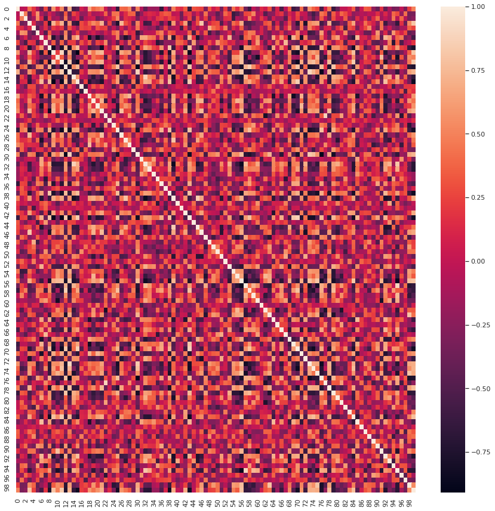

```python
### CORRELATION PLOT OF FEATURES ###
corr_matF = F.corr().round(2)
fix, ax = plt.subplots(figsize=(15,15))
sns.heatmap(data = corr_matF, annot=False)
```

*ADJACENCY MATRIX*

```python
### ADJACENCY MATRIX A ###
A = pd.read_csv("/content/karate_club_graph.csv")
A.drop(A.columns[[0]], axis=1, inplace=True) #delete first column
A.head()
```

|  | 0 | 1 | 2 | 3 | 4 | 5 | 6 | 7 | 8 | 9 | 10 | 11 | 12 | 13 | 14 | 15 | 16 | 17 | 18 | 19 | 20 | 21 | 22 | 23 | 24 | 25 | 26 | 27 | 28 | … |
| --- | --- | --- | --- | --- | --- | --- | --- | --- | --- | --- | --- | --- | --- | --- | --- | --- | --- | --- | --- | --- | --- | --- | --- | --- | --- | --- | --- | --- | --- | --- |
| 0 | 0.0 | 1.0 | 1.0 | 1.0 | 1.0 | 1.0 | 1.0 | 1.0 | 1.0 | 0.0 | 1.0 | 1.0 | 1.0 | 1.0 | 0.0 | 0.0 | 0.0 | 1.0 | 0.0 | 1.0 | 0.0 | 1.0 | 0.0 | 0.0 | 0.0 | 0.0 | 0.0 | 0.0 | 0.0 | … |
| 1 | 1.0 | 0.0 | 1.0 | 1.0 | 0.0 | 0.0 | 0.0 | 1.0 | 0.0 | 0.0 | 0.0 | 0.0 | 0.0 | 1.0 | 0.0 | 0.0 | 0.0 | 1.0 | 0.0 | 1.0 | 0.0 | 1.0 | 0.0 | 0.0 | 0.0 | 0.0 | 0.0 | 0.0 | 0.0 | … |
| 2 | 1.0 | 1.0 | 0.0 | 1.0 | 0.0 | 0.0 | 0.0 | 1.0 | 1.0 | 1.0 | 0.0 | 0.0 | 0.0 | 1.0 | 0.0 | 0.0 | 0.0 | 0.0 | 0.0 | 0.0 | 0.0 | 0.0 | 0.0 | 0.0 | 0.0 | 0.0 | 0.0 | 1.0 | 1.0 | … |
| 3 | 1.0 | 1.0 | 1.0 | 0.0 | 0.0 | 0.0 | 0.0 | 1.0 | 0.0 | 0.0 | 0.0 | 0.0 | 1.0 | 1.0 | 0.0 | 0.0 | 0.0 | 0.0 | 0.0 | 0.0 | 0.0 | 0.0 | 0.0 | 0.0 | 0.0 | 0.0 | 0.0 | 0.0 | 0.0 | … |
| 4 | 1.0 | 0.0 | 0.0 | 0.0 | 0.0 | 0.0 | 1.0 | 0.0 | 0.0 | 0.0 | 1.0 | 0.0 | 0.0 | 0.0 | 0.0 | 0.0 | 0.0 | 0.0 | 0.0 | 0.0 | 0.0 | 0.0 | 0.0 | 0.0 | 0.0 | 0.0 | 0.0 | 0.0 | 0.0 | … |

```python
### CHECK NUMBER OF UNIQUE VALUES PER FEATURE ###
A.nunique()
```

```
0     2
1     2
2     2
3     2
4     2
5     2
6     2
7     2
8     2
9     2
10    2
11    2
12    2
13    2
14    2
```

[output cut: 20 more lines]

```python
A.describe()
```

|  | 0 | 1 | 2 | 3 | 4 | 5 | 6 | 7 | 8 | 9 | 10 | 11 | 12 | 13 | 14 | 15 | 16 | 17 | 18 | 19 | 20 | 21 | 22 | 23 | 24 | 25 | 26 | 27 | 28 | … |
| --- | --- | --- | --- | --- | --- | --- | --- | --- | --- | --- | --- | --- | --- | --- | --- | --- | --- | --- | --- | --- | --- | --- | --- | --- | --- | --- | --- | --- | --- | --- |
| count | 34.000000 | 34.000000 | 34.000000 | 34.000000 | 34.000000 | 34.000000 | 34.000000 | 34.000000 | 34.000000 | 34.000000 | 34.000000 | 34.000000 | 34.000000 | 34.000000 | 34.000000 | 34.000000 | 34.000000 | 34.000000 | 34.000000 | 34.000000 | 34.000000 | 34.000000 | 34.000000 | 34.000000 | 34.000000 | 34.000000 | 34.000000 | 34.000000 | 34.000000 | … |
| mean | 0.470588 | 0.264706 | 0.294118 | 0.176471 | 0.088235 | 0.117647 | 0.117647 | 0.117647 | 0.147059 | 0.058824 | 0.088235 | 0.029412 | 0.058824 | 0.147059 | 0.058824 | 0.058824 | 0.058824 | 0.058824 | 0.058824 | 0.088235 | 0.058824 | 0.058824 | 0.058824 | 0.147059 | 0.088235 | 0.088235 | 0.058824 | 0.117647 | 0.088235 | … |
| std | 0.506640 | 0.447811 | 0.462497 | 0.386953 | 0.287902 | 0.327035 | 0.327035 | 0.327035 | 0.359491 | 0.238833 | 0.287902 | 0.171499 | 0.238833 | 0.359491 | 0.238833 | 0.238833 | 0.238833 | 0.238833 | 0.238833 | 0.287902 | 0.238833 | 0.238833 | 0.238833 | 0.359491 | 0.287902 | 0.287902 | 0.238833 | 0.327035 | 0.287902 | … |
| min | 0.000000 | 0.000000 | 0.000000 | 0.000000 | 0.000000 | 0.000000 | 0.000000 | 0.000000 | 0.000000 | 0.000000 | 0.000000 | 0.000000 | 0.000000 | 0.000000 | 0.000000 | 0.000000 | 0.000000 | 0.000000 | 0.000000 | 0.000000 | 0.000000 | 0.000000 | 0.000000 | 0.000000 | 0.000000 | 0.000000 | 0.000000 | 0.000000 | 0.000000 | … |
| 25% | 0.000000 | 0.000000 | 0.000000 | 0.000000 | 0.000000 | 0.000000 | 0.000000 | 0.000000 | 0.000000 | 0.000000 | 0.000000 | 0.000000 | 0.000000 | 0.000000 | 0.000000 | 0.000000 | 0.000000 | 0.000000 | 0.000000 | 0.000000 | 0.000000 | 0.000000 | 0.000000 | 0.000000 | 0.000000 | 0.000000 | 0.000000 | 0.000000 | 0.000000 | … |
| 50% | 0.000000 | 0.000000 | 0.000000 | 0.000000 | 0.000000 | 0.000000 | 0.000000 | 0.000000 | 0.000000 | 0.000000 | 0.000000 | 0.000000 | 0.000000 | 0.000000 | 0.000000 | 0.000000 | 0.000000 | 0.000000 | 0.000000 | 0.000000 | 0.000000 | 0.000000 | 0.000000 | 0.000000 | 0.000000 | 0.000000 | 0.000000 | 0.000000 | 0.000000 | … |
| 75% | 1.000000 | 0.750000 | 1.000000 | 0.000000 | 0.000000 | 0.000000 | 0.000000 | 0.000000 | 0.000000 | 0.000000 | 0.000000 | 0.000000 | 0.000000 | 0.000000 | 0.000000 | 0.000000 | 0.000000 | 0.000000 | 0.000000 | 0.000000 | 0.000000 | 0.000000 | 0.000000 | 0.000000 | 0.000000 | 0.000000 | 0.000000 | 0.000000 | 0.000000 | … |
| max | 1.000000 | 1.000000 | 1.000000 | 1.000000 | 1.000000 | 1.000000 | 1.000000 | 1.000000 | 1.000000 | 1.000000 | 1.000000 | 1.000000 | 1.000000 | 1.000000 | 1.000000 | 1.000000 | 1.000000 | 1.000000 | 1.000000 | 1.000000 | 1.000000 | 1.000000 | 1.000000 | 1.000000 | 1.000000 | 1.000000 | 1.000000 | 1.000000 | 1.000000 | … |

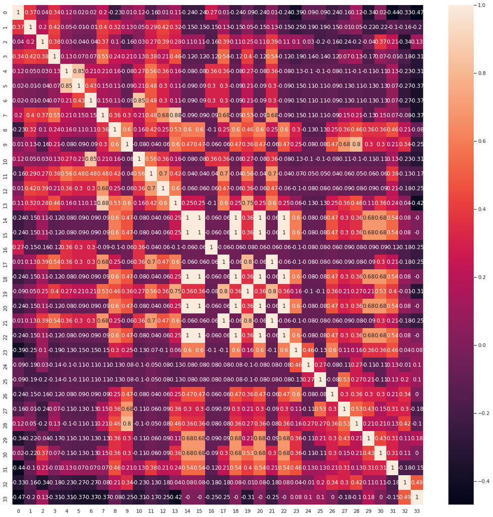

```python
### CORRELATION MATRIX ###
corr_matA = A.corr().round(2)
fix, ax = plt.subplots(figsize=(20,20))
sns.heatmap(data = corr_matA, annot=True)
```

We can see that a few nodes are highly correlated.

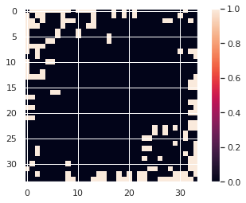

```python
# plot a heatmap of the distance matrix # KEEP OR NOT?
plt.imshow(A)
plt.colorbar();
```

*GROUND TRUTH*

```python
# Ground truth
GT = pd.read_csv("/content/ground_truth_karate_club.csv")
GT.drop(GT.columns[[0]], axis=1, inplace=True) #delete first column
GT.head()
```

|  | 0 |
| --- | --- |
| 0 | Mr. Hi |
| 1 | Mr. Hi |
| 2 | Mr. Hi |
| 3 | Mr. Hi |
| 4 | Mr. Hi |

# 2.1 Clustering of the feature matrix

In this first task, we are implementing a k-means algorithm to compute a clustering of the feature matrix using NumPy only.

## 2.1.0 Load and normalize data

First of all, let's load and normalize the data.

```python
### IMPORT NECESSARY PACKAGES ###
import numpy as np
import pandas as pd
import seaborn as sns
import matplotlib.pyplot as plt
import scipy as sc
```

```python
### LOAD FEATURE MATRIX ###
F = pd.read_csv("/content/feature_matrix_karate_club.csv")
F.drop(F.columns[[0]], axis=1, inplace=True) #delete first column
F.head()
```

|  | 0 | 1 | 2 | 3 | 4 | 5 | 6 | 7 | 8 | 9 | 10 | 11 | 12 | 13 | 14 | 15 | 16 | 17 | 18 | 19 | 20 | 21 | 22 | 23 | 24 | 25 | 26 | 27 | 28 | … |
| --- | --- | --- | --- | --- | --- | --- | --- | --- | --- | --- | --- | --- | --- | --- | --- | --- | --- | --- | --- | --- | --- | --- | --- | --- | --- | --- | --- | --- | --- | --- |
| 0 | 0.148640 | -0.187110 | -0.109395 | 0.111767 | -0.024913 | -0.117825 | -0.072237 | 0.109746 | -0.088250 | 0.210684 | 0.150548 | 0.073093 | 0.123050 | 0.013435 | 0.030419 | -0.054971 | -0.024773 | 0.027176 | -0.031192 | 0.244318 | -0.023978 | 0.063524 | -0.017616 | 0.015206 | 0.021023 | -0.166403 | -0.054085 | -0.107196 | 0.001245 | … |
| 1 | 0.207001 | -0.018979 | -0.094483 | 0.013424 | -0.106083 | 0.252485 | 0.092830 | 0.002718 | 0.224389 | 0.061539 | -0.011964 | -0.124062 | 0.363754 | -0.186012 | 0.005853 | 0.154634 | -0.007437 | -0.056847 | -0.153121 | 0.155806 | 0.005505 | -0.009769 | 0.129684 | -0.140923 | 0.107991 | -0.089491 | -0.159392 | -0.118141 | -0.028254 | … |
| 2 | 0.093962 | -0.262451 | -0.033010 | 0.108551 | 0.008679 | -0.077413 | 0.051345 | 0.082396 | -0.020187 | 0.186536 | 0.089231 | 0.135319 | 0.090328 | 0.024973 | -0.015908 | -0.023561 | -0.014670 | 0.080317 | -0.047213 | 0.214932 | -0.047513 | -0.026536 | -0.035187 | -0.097793 | 0.019769 | -0.127663 | -0.161302 | -0.109478 | -0.059508 | … |
| 3 | 0.212280 | -0.047187 | -0.116486 | -0.004627 | 0.025335 | 0.020590 | -0.123587 | 0.059001 | -0.034748 | 0.131113 | 0.042459 | 0.030327 | 0.337262 | 0.129351 | 0.088097 | 0.101446 | -0.071444 | -0.023532 | 0.071519 | 0.065602 | 0.054506 | -0.076591 | 0.160769 | -0.068860 | 0.166010 | -0.108786 | -0.107945 | 0.052027 | 0.183210 | … |
| 4 | 0.053653 | 0.122337 | -0.135267 | -0.017862 | -0.012216 | 0.064982 | -0.053867 | 0.120750 | -0.060154 | 0.204295 | -0.206539 | -0.015263 | 0.217170 | -0.148366 | 0.180569 | 0.013032 | 0.105246 | -0.148139 | -0.116360 | 0.170930 | -0.001771 | 0.112156 | 0.231537 | -0.041038 | 0.044176 | 0.008420 | -0.040560 | -0.250178 | 0.083283 | … |

5 rows × 100 columns

```python
F.shape #shape is coherent with exercise, N=34 samples and p=100 features capturing different traits
```

```
(34, 100)
```

```python
F = F.to_numpy() # transform to DataFrame to numpy array
```

```python
def normalize(X): # normalize function
    mu = np.mean(X, axis=0)
    std = np.std(X, axis=0)
    std_filled = std.copy()
    std_filled[std==0] = 1.
    Xbar = ((X-mu)/std_filled)
    return Xbar
```

```python
F = normalize(F) # normalize data
```

## 2.1.1 Obtain optimised clusterings for k-means according to within distance

First of all, let's define a k-means algorithm and iterate 100 times over different values of k from 2 to 10 and average.

We then plot the average within-cluster distance as a function of k.

Let's define the within-cluster distance as follows:

$W_k = \sum_{i=1}^k \sum_{x\in C_q} (x-c_q)(x-c_q)^T$, where $C_q$ is the set of points in cluster q and $c_q$ is the center of the cluster q.

```python
### K MEANS ALGORITHM from CT ###

def k_means(k, X, max_iter):
    n_samples, n_features = X.shape

    labels = np.random.randint(low=0, high=k, size=n_samples)

    while (len(np.unique(labels)) < k): # make sure there are no empty clusters assigned in the initialization
        labels = np.random.randint(low=0, high=k, size=n_samples)

    X_labels = np.append(X, labels.reshape(-1,1), axis=1)
    centroids = np.zeros((k, n_features))

    for i in range(k):
        centroids[i] = np.mean([x for x in X_labels if x[-1]==i], axis=0)[0:n_features]

    #iterations
    new_labels = np.zeros(len(X))
    difference = 0

    for i in range(max_iter):
        # distances: between data points and centroids
        distances = np.array([np.linalg.norm(X - c, axis=1) for c in centroids])
        # new_labels: computed by finding centroid with minimal distance
        new_labels = np.argmin(distances, axis=0)

        if (labels==new_labels).all():
            # labels unchanged
            labels = new_labels
            break
        else:
            # labels changed
            # difference: percentage of changed labels
            difference = np.mean(labels!=new_labels)
            labels = new_labels
            for c in range(k):
                if len(X[labels==c])>0:
                # computing centroids by taking the mean over associated data points
                    centroids[c] = np.mean(X[labels==c], axis=0)
                else: # make sure that if any clusters are empty at the end, we assign a random number to it so that it doesn't stay empty
                    centroids[c] = X[np.random.randint(low=0, high=len(X), size=1)]
    return centroids, labels
```

```python
### WITHIN DISTANCE FUNCTION ###

def within_distance2(X, k, labels, centroids):
    W = 0 # initalize distance for summation
    N = X.shape[0]
    for c in range(k): # double sum for matrix filling
        for i in range(N):
            if labels[i]==c:
                W += ( (X[i]-centroids[c]) @ (X[i]-centroids[c]).T)
    return W
```

Now that we have defined our 2 main functions, we can loop over 100 iterations, and different values of k to find the average within distance.

```python
### Loop over 100 random initialisation for k means between 2 and 10 ###

centroids, labels = [], []
max_iter = 15
W = np.zeros(9)

for i in range(100):
    for k in range(2,11):
        centroids, labels = k_means(k, F, max_iter)
        # compute within cluster distance
        W[k-2] += within_distance2(F, k, labels, centroids)/100
```

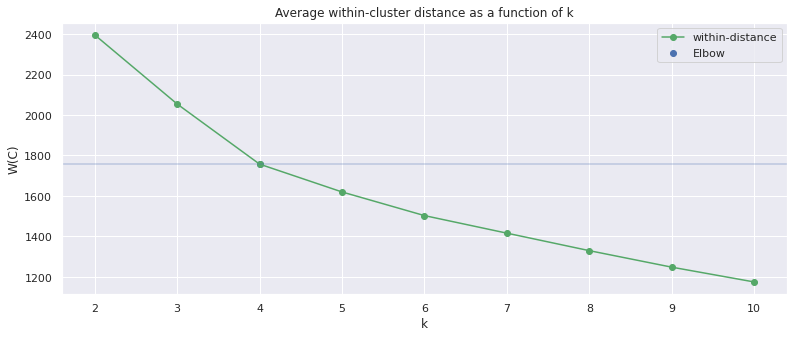

```
4 is the optimal number of clusters.
```

```python
### Plot of the average within-cluster distance as a function of k ###

import matplotlib.pyplot as plt
import seaborn as sns
k = np.arange(2,11,1)

sns.set()

plt.figure(figsize=(13,5))
plt.plot(k, W, '-o', color='g', label='within-distance')
plt.axhline(y=W[k==4], c='b', alpha=0.3)
plt.scatter(k[2], W[k==4], color='b', label='Elbow')
plt.title("Average within-cluster distance as a function of k")
plt.xlabel("k")
plt.ylabel("W(C)")
plt.legend()
plt.show()

k_optimal = k[2]
print('{} is the optimal number of clusters.'.format(k[2]))
```

It is not obvious that the elbow is at k=4. It does look like it, but we might wonder what about k=2?.

So let's try a different range for our k-means starting at 1 clusters:

```python
### Loop over 100 random initialisation for k means between 1 and 9 ###

centroids, labels = [], []
max_iter = 15
W1 = np.zeros(9)

for i in range(100):
    for k in range(1,10):
        centroids, labels = k_means(k, F, max_iter)
        # compute within cluster distance
        W1[k-1] += within_distance2(F, k, labels, centroids)/100
```

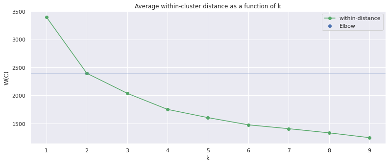

```
2 is the optimal number of clusters.
```

```python
### Plot of the average within-cluster distance as a function of k ###

import matplotlib.pyplot as plt
import seaborn as sns
k = np.arange(1,10,1)

sns.set()

plt.figure(figsize=(13,5))
plt.plot(k, W1, '-o', color='g', label='within-distance')
plt.axhline(y=W1[k==2], c='b', alpha=0.3)
plt.scatter(k[1], W1[k==2], color='b', label='Elbow')
plt.title("Average within-cluster distance as a function of k")
plt.xlabel("k")
plt.ylabel("W(C)")
plt.legend()
plt.show()

k_optimal = k[2]
print('{} is the optimal number of clusters.'.format(k[1]))
```

We see that k=2 is the optimal number of clusters when we change the range of k-means to look at. We will see later that actually the CH score agrees with that but nevertheless, the task asked to look for an elbow in the range $[2,10]$, in that case, our elbow comes for $k=4$ clusters.

**Comment**

From this method, the elbow seems to be around $k=4$. However it is not really obvious. In fact, if we plot on different numbers of clusters we see a clearer elbow at $k=2$. We will see later that in fact with another metric: the CH score confirms that different hypothesis of having in fact only 2 clusters.

## 2.1.2 Obtain optimal clustering for k means according to CH score

Now, let's code the Calinski-Harabasz score (CH score) and plot it as a function of increasing k to find the optimal clustering according to that score.

Essentially we want to find the k for which the CH score is the highest.

Mathematically, we can define the CH score as follows:

$CH = \frac{tr(W_k)}{tr(B_k)} \frac{n_E - k}{k-1}$, tr is the trace of the matrix

where we have defined

- the within distance: $W_k = \sum_{q=1}^k \sum_{x\in C_q} (x-c_q)(x-c_q)^T$
- the between distance: $B_k = \sum_{q=1}^k n_q (c_q-c_E)(c_q-c_E)^T$.

And where $C_q$ is the set of points in cluster q, $c_q$ is the center of the cluster q, $c_E$ is the center of E and $n_q$ the number of points in clusters q (for a set $E$ of size $n_E$).

```python
### BETWEEN DISTANCE FUNCTION ###

def between_distance(X, k, labels, centroids):
    mean = np.mean(X, axis=0)
    distance = 0 # initialize summation

    for c in range(k): # loop over number of clusters
        idx = sum(j==c for j in labels) # number of points in cluster k
        distance += idx * ((centroids[c]-mean)@(centroids[c]-mean).T)
    return distance
```

```python
### CALINSKI HARABASZ SCORE FUNCTION ###

def CH_score(X, k, labels, centroids):
    N = X.shape[0] # number of samples

    B = between_distance(X,k,labels,centroids) # compute between distance
    W = within_distance2(X,k,labels,centroids) # compute within distance

    CH = B/W * (N-k)/(k-1) # compute actual score
    return CH
```

Now, let's do 100 iterations over our k-means and computing our CH score to average it and plot.

```python
### Loop over 100 random initialisation for k means between 2 and 10 ###

centroids, labels = [], []
max_iter = 15
CH = np.zeros(9)

for j in range(100):
    for k in range(2,11):
        centroids, labels = k_means(k, F, max_iter)
        # compute CH score
        CH[k-2] += CH_score(F, k, labels, centroids)/100
```

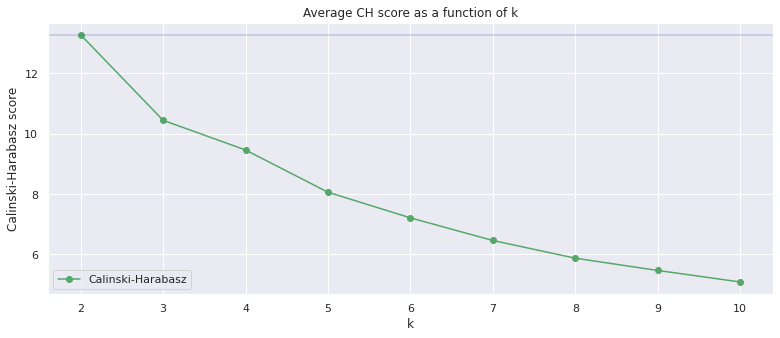

```
2 is the optimal number of clusters.
```

```python
### Plot of the average CH score as a function of k ###

import matplotlib.pyplot as plt

k = np.arange(2,11,1)
sns.set()

plt.figure(figsize=(13,5))
plt.plot(k, CH,'-o', color='g', label='Calinski-Harabasz')
plt.axhline(y=max(CH), c='b', alpha=0.3)
plt.title("Average CH score as a function of k")
plt.xlabel("k")
plt.ylabel("Calinski-Harabasz score")
plt.legend()
plt.show()

k_optimal = k[np.argmax(CH)]
print('{} is the optimal number of clusters.'.format(k[np.argmax(CH)]))
```

**Comment**

Thanks to the CH score, we find that the best k is 2, because that's the k for which our CH score is the highest.

## 2.1.3 Evaluation of robustness of k means

In this part, we want to evaluate how robust our k-means clustering is. We will do that by exploring the variance of our k over 100 iterations and also by looking at the ARI score that is defined a bit later in the coursework.

```python
### Compute quartiles for our within-distance ###

max_iter = 15
W2, W3, W4, W5, W6, W7, W8, W9, W10 = [], [], [], [], [], [], [], [], []

for j in range(100):
    c2, l2 = k_means(2, F, max_iter)
    c3, l3 = k_means(3, F, max_iter)
    c4, l4 = k_means(4, F, max_iter)
    c5, l5 = k_means(5, F, max_iter)
    c6, l6 = k_means(6, F, max_iter)
    c7, l7 = k_means(7, F, max_iter)
    c8, l8 = k_means(8, F, max_iter)
    c9, l9 = k_means(9, F, max_iter)
    c10, l10 = k_means(10, F, max_iter)
    W2.append(within_distance2(F, 2, l2, c2))
    W3.append(within_distance2(F, 3, l3, c3))
    W4.append(within_distance2(F, 4, l4, c4))
    W5.append(within_distance2(F, 5, l5, c5))
    W6.append(within_distance2(F, 6, l6, c6))
    W7.append(within_distance2(F, 7, l7, c7))
    W8.append(within_distance2(F, 8, l8, c8))
    W9.append(within_distance2(F, 9, l9, c9))
    W10.append(within_distance2(F, 10, l10, c10))
```

```python
### Compute 1st & 3rd quantile for each k and stack them ###

q21, q23 = np.percentile(W2, 25), np.percentile(W2, 75)
q31, q33 = np.percentile(W3, 25), np.percentile(W3, 75)
q41, q43 = np.percentile(W4, 25), np.percentile(W4, 75)
q51, q53 = np.percentile(W5, 25), np.percentile(W5, 75)
q61, q63 = np.percentile(W6, 25), np.percentile(W6, 75)
q71, q73 = np.percentile(W7, 25), np.percentile(W7, 75)
q81, q83 = np.percentile(W8, 25), np.percentile(W8, 75)
q91, q93 = np.percentile(W9, 25), np.percentile(W9, 75)
q101, q103 = np.percentile(W10, 25), np.percentile(W10, 75)

q1 = np.stack((q21, q31, q41, q51, q61, q71, q81, q91, q101))
q3 = np.stack((q23, q33, q43, q53, q63, q73, q83, q93, q103))
```

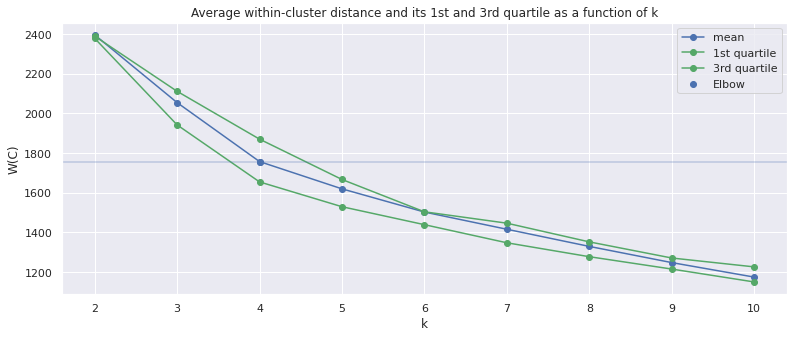

```python
### Plot of the average within-cluster distance and its 1st and 3rd quartile as a function of k ###
import matplotlib.pyplot as plt

k = np.arange(2,11,1)
sns.set()

plt.figure(figsize=(13,5))
plt.plot(k, W, '-o', color='b', label='mean')
plt.plot(k, q1, '-o', color='g', label='1st quartile')
plt.plot(k, q3, '-o', color='g', label='3rd quartile')

plt.axhline(y=W[k==4], c='b', alpha=0.3)
plt.scatter(k[2], W[k==4], color='b', label='Elbow')
plt.title("Average within-cluster distance and its 1st and 3rd quartile as a function of k")
plt.xlabel("k")
plt.ylabel("W(C)")
plt.legend()

plt.show()
```

**Comment**

This plot shows that for k=2, the variance of the within distance is extremely low (as 1st and 3rd quartile are on the same point as the mean), which makes our assumption that k=2 from the CH score is the best clustering fairly robutst. Because essentially it means that over 100 iterations, the clusterings are all very very similar. However, regarding k=3 and k=4 say, we see that the variance is wider so clustering is more volatile and less relient.

```python
### CREATE CONSISTENCY TABLE FUNCTION ### CHANGE ARI

def cons_t(c1, c2):

    N = c1.size # pick length of cluster 1 vector

    # pick vector from cluster 2 with the number of unique entries
    n1 = np.unique(c2)
    N1 = n1.size

    # pick vector from cluster 2 with the number of unique entries
    n2 = np.unique(c1)
    N2 = n2.size

    # ininitialize consistency table to fill
    cons_t = np.zeros((N2+1, N1+1))

    for i in range(N): # loop over cluster size
        cons_t[c1[i], c2[i]] += 1 # update

    # define sum of rows and columns
    s_1 = np.sum(cons_t, axis=1) # column sum
    s_2 = np.sum(cons_t, axis=0) # row sum

    for j in range(N2): # loop over number of unique entries
        cons_t[j, N1] = s_1[j] # update

    for k in range(N1): # loop over number of unique entries
        cons_t[N2, k] = s_2[k] # update

    return cons_t
```

```python
### CREATE ADJUSTED RAND INDEX FUNCTION ###

def ARI(c1, c2):

    # sums from top of fraction
    s_top_1 = 0
    s_top_2 = 0
    # sums from 2nd term of top of fraction
    s_top_21= 0
    s_top_22= 0

    # sums from bottom of fraction
    s_bottom_1 = 0
    s_bottom_2 = 0

    n = c1.size

    # choose unique values from c2
    n1 = np.unique(c2)
    N1 = n1.size

    # choose unique values from c1
    n2 = np.unique(c1)
    N2 = n2.size

    # create initial CT
    CT = cons_t(c1,c2)

    # double loop for first term of top of fraction
    for k in range(N2):
        for l in range(N1):
            s_top_1 += sc.special.binom(CT[k,l],2)

    # compute first sum of second term of top of fraction
    for k in range(N2):
        s_top_21 += sc.special.binom(CT[k,N1],2)

    # compute second sum of second term of top of fraction
    for l in range(N1):
        s_top_22 += sc.special.binom(CT[N2,l],2)

    # divide 2nd term of top of fraction by the combinatorics
    s_top_2 = s_top_21 * s_top_22 / sc.special.binom(n,2)

    # compute first sum from bottom of frac
    for k in range(N2):
        s_bottom_1 += sc.special.binom(CT[k,N1],2)

    for l in range(N1):
        s_bottom_1 += sc.special.binom(CT[N2,l],2)

    s_bottom_1 /= 2 #result for first sum from bottom of frac

    # compute seond sum from bottom of frac
    s_bottom_2 = s_top_2

    return (s_top_1 - s_top_2)/(s_bottom_1-s_bottom_2)
```

```python
### LOOK AT ARI FOR 2 SOLUTIONS 100 ITERATIONS OF K-MEANS FOR K=2 ###
labels21=[]
labels22=[]
ARI2 = []
for i in range(100):
  centroids201, labels201 = k_means(2, F, 15)
  centroids202, labels202 = k_means(2, F, 15)
  labels21.append(np.array(labels201))
  labels22.append(np.array(labels202))
  ARI2.append(ARI(np.array(labels21[i-1]), np.array(labels22[i-1])))

kari2 = np.mean(ARI2)
```

```python
### LOOK AT ARI FOR 2 SOLUTIONS 100 ITERATIONS OF K-MEANS FOR K=3 ###

# initialize empty vectors to append
labels31=[]
labels32=[]
ARI3 = []
for i in range(100): # loop 100 times
  centroids301, labels301 = k_means(3, F, 15)
  centroids302, labels302 = k_means(3, F, 15)
  labels31.append(np.array(labels301)) # create a vector of 100 solutions of k-means for k=3
  labels32.append(np.array(labels302)) # create a vector of 100 solutions of k-means for k=3
  ARI3.append(ARI(np.array(labels31[i-1]), np.array(labels32[i-1]))) # compare pairwise

kari3 = np.mean(ARI3) # compute mean
```

```python
### LOOK AT ARI FOR 2 SOLUTIONS 100 ITERATIONS OF K-MEANS FOR K=4 ###
labels41=[]
labels42=[]
ARI4 = []
for i in range(100):
  centroids401, labels401 = k_means(4, F, 15)
  centroids402, labels402 = k_means(4, F, 15)
  labels41.append(np.array(labels401))
  labels42.append(np.array(labels402))
  ARI4.append(ARI(np.array(labels41[i-1]), np.array(labels42[i-1])))

kari4 = np.mean(ARI4)
```

```python
### LOOK AT ARI FOR 2 SOLUTIONS 100 ITERATIONS OF K-MEANS FOR K=5 ###
labels51=[]
labels52=[]
ARI5 = []
for i in range(100):
  centroids501, labels501 = k_means(5, F, 15)
  centroids502, labels502 = k_means(5, F, 15)
  labels51.append(np.array(labels501))
  labels52.append(np.array(labels502))
  ARI5.append(ARI(np.array(labels51[i-1]), np.array(labels52[i-1])))

kari5 = np.mean(ARI5)
```

```python
### LOOK AT ARI FOR 2 SOLUTIONS 100 ITERATIONS OF K-MEANS FOR K=6 ###
labels61=[]
labels62=[]
ARI6 = []
for i in range(100):
  centroids601, labels601 = k_means(6, F, 15)
  centroids602, labels602 = k_means(6, F, 15)
  labels61.append(np.array(labels601))
  labels62.append(np.array(labels602))
  ARI6.append(ARI(np.array(labels61[i-1]), np.array(labels62[i-1])))

kari6 = np.mean(ARI6)
```

```python
### LOOK AT ARI FOR 2 SOLUTIONS 100 ITERATIONS OF K-MEANS FOR K=7 ###
labels71=[]
labels72=[]
ARI7 = []
for i in range(100):
  centroids701, labels701 = k_means(7, F, 15)
  centroids702, labels702 = k_means(7, F, 15)
  labels71.append(np.array(labels701))
  labels72.append(np.array(labels702))
  ARI7.append(ARI(np.array(labels71[i-1]), np.array(labels72[i-1])))

kari7 = np.mean(ARI7)
```

```python
### LOOK AT ARI FOR 2 SOLUTIONS 100 ITERATIONS OF K-MEANS FOR K=8 ###
labels81=[]
labels82=[]
ARI8 = []
for i in range(100):
  centroids801, labels801 = k_means(8, F, 15)
  centroids802, labels802 = k_means(8, F, 15)
  labels81.append(np.array(labels801))
  labels82.append(np.array(labels802))
  ARI8.append(ARI(np.array(labels81[i-1]), np.array(labels82[i-1])))

kari8 = np.mean(ARI8)
```

```python
### LOOK AT ARI FOR 2 SOLUTIONS 100 ITERATIONS OF K-MEANS FOR K=9 ###
labels91=[]
labels92=[]
ARI9 = []
for i in range(100):
  centroids901, labels901 = k_means(9, F, 15)
  centroids902, labels902 = k_means(9, F, 15)
  labels91.append(np.array(labels901))
  labels92.append(np.array(labels902))
  ARI9.append(ARI(np.array(labels91[i-1]), np.array(labels92[i-1])))

kari9 = np.mean(ARI9)
```

```python
### LOOK AT ARI FOR 2 SOLUTIONS 100 ITERATIONS OF K-MEANS FOR K=10 ###
labels101=[]
labels102=[]
ARI10 = []
for i in range(100):
  centroids1001, labels1001 = k_means(10, F, 15)
  centroids1002, labels1002 = k_means(10, F, 15)
  labels101.append(np.array(labels1001))
  labels102.append(np.array(labels1002))
  ARI10.append(ARI(np.array(labels101[i-1]), np.array(labels102[i-1])))

kari10 = np.mean(ARI10)
```

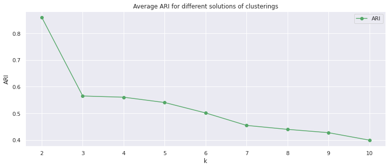

```python
### PLOT RESULTS FOR ARI WRT TO DIFFERENT NUMBER OF CLUSTERS ###

kari= [kari2, kari3, kari4, kari5, kari6, kari7, kari8, kari9, kari10]
k = np.arange(2,11,1)
sns.set()

plt.figure(figsize=(13,5))
plt.plot(k, kari, '-o', color='g', label='ARI')
plt.title("Average ARI for different solutions of clusterings")
plt.xlabel("k")
plt.ylabel("ARI")
plt.legend()

plt.show()
```

**Comment**

The ARI score of our different solutions against the number of clusters shows that actually, the best k is k=2. Indeed it has the highest ARI score, which indicates that even throughout random initialization, our solutions for clustering are consistent with each other. However when we increase the number of clusters, as seen with the quartiles plot and this one too, the variability in clustering solutions increases and so the solutions are less robust.

In conclusion, the combination of the variance analysis (k=2) of the within distance, the ARI score (k=2) and the CH score (k=2) could push us to choose k=2 as the best cluster.

# 2.2 Dimensionality reduction of the feature matrix

In this part, we look at Principal Component Analysis to carry out dimensionality reduction on the feature matrix. Indeed we have 100 features on only 34 samples, so it is quite hard to understand how all these datapoints interact with each other. Therefore, let's try to capture as much variability in the data as possible in fewer dimensions.

## 2.2.0 Load & normalize data

```python
### IMPORT NECESSARY PACKAGES ###
import numpy as np
import pandas as pd
import matplotlib.pyplot as plt
import scipy as sc
```

```python
### LOAD FEATURE MATRIX ###
F = pd.read_csv("/content/feature_matrix_karate_club.csv")
F.drop(F.columns[[0]], axis=1, inplace=True) #delete first column
F.head()
```

|  | 0 | 1 | 2 | 3 | 4 | 5 | 6 | 7 | 8 | 9 | 10 | 11 | 12 | 13 | 14 | 15 | 16 | 17 | 18 | 19 | 20 | 21 | 22 | 23 | 24 | 25 | 26 | 27 | 28 | … |
| --- | --- | --- | --- | --- | --- | --- | --- | --- | --- | --- | --- | --- | --- | --- | --- | --- | --- | --- | --- | --- | --- | --- | --- | --- | --- | --- | --- | --- | --- | --- |
| 0 | 0.148640 | -0.187110 | -0.109395 | 0.111767 | -0.024913 | -0.117825 | -0.072237 | 0.109746 | -0.088250 | 0.210684 | 0.150548 | 0.073093 | 0.123050 | 0.013435 | 0.030419 | -0.054971 | -0.024773 | 0.027176 | -0.031192 | 0.244318 | -0.023978 | 0.063524 | -0.017616 | 0.015206 | 0.021023 | -0.166403 | -0.054085 | -0.107196 | 0.001245 | … |
| 1 | 0.207001 | -0.018979 | -0.094483 | 0.013424 | -0.106083 | 0.252485 | 0.092830 | 0.002718 | 0.224389 | 0.061539 | -0.011964 | -0.124062 | 0.363754 | -0.186012 | 0.005853 | 0.154634 | -0.007437 | -0.056847 | -0.153121 | 0.155806 | 0.005505 | -0.009769 | 0.129684 | -0.140923 | 0.107991 | -0.089491 | -0.159392 | -0.118141 | -0.028254 | … |
| 2 | 0.093962 | -0.262451 | -0.033010 | 0.108551 | 0.008679 | -0.077413 | 0.051345 | 0.082396 | -0.020187 | 0.186536 | 0.089231 | 0.135319 | 0.090328 | 0.024973 | -0.015908 | -0.023561 | -0.014670 | 0.080317 | -0.047213 | 0.214932 | -0.047513 | -0.026536 | -0.035187 | -0.097793 | 0.019769 | -0.127663 | -0.161302 | -0.109478 | -0.059508 | … |
| 3 | 0.212280 | -0.047187 | -0.116486 | -0.004627 | 0.025335 | 0.020590 | -0.123587 | 0.059001 | -0.034748 | 0.131113 | 0.042459 | 0.030327 | 0.337262 | 0.129351 | 0.088097 | 0.101446 | -0.071444 | -0.023532 | 0.071519 | 0.065602 | 0.054506 | -0.076591 | 0.160769 | -0.068860 | 0.166010 | -0.108786 | -0.107945 | 0.052027 | 0.183210 | … |
| 4 | 0.053653 | 0.122337 | -0.135267 | -0.017862 | -0.012216 | 0.064982 | -0.053867 | 0.120750 | -0.060154 | 0.204295 | -0.206539 | -0.015263 | 0.217170 | -0.148366 | 0.180569 | 0.013032 | 0.105246 | -0.148139 | -0.116360 | 0.170930 | -0.001771 | 0.112156 | 0.231537 | -0.041038 | 0.044176 | 0.008420 | -0.040560 | -0.250178 | 0.083283 | … |

5 rows × 100 columns

```python
### TRANSFORM TO NUMPY ARRAY###
F = F.to_numpy()
```

```python
### NORMALIZE FUNCTION ###
def normalize(X):
    mu = np.mean(X, axis=0)
    std = np.std(X, axis=0)
    std_filled = std.copy()
    std_filled[std==0] = 1.
    Xbar = ((X-mu)/std_filled)
    return Xbar
```

```python
F = normalize(F) # normalize feature
```

```python
print(F)
```

```
[[ 0.74887402 -1.39730361 -0.48929966 ... -0.28512148  0.13252166
   0.26538724]
 [ 1.53093264  0.25719319 -0.25244759 ... -1.10116311 -1.14727011
  -0.61985789]
 [ 0.01616094 -2.1387055   0.72392518 ... -1.85094005  0.10920858
   0.85215522]
 ...
 [-0.2830589   0.6513791   0.79281966 ...  0.57247145 -1.03630708
  -0.68431521]
 [ 0.9547694  -0.84102227 -0.95349772 ... -0.49432713  1.38469424
   0.73618725]
 [-1.29672531 -0.60330908 -0.38802066 ...  0.13062611 -1.18517828
  -0.28073908]]
```

## 2.2.1 Plot of data with respect to d-dimensional PCA space

In this first task, we are asked to plot our data in 3 different dimensions of the PCA space: for d=1, d=2 and d=3.

In order to do that, we need to implement dimensional reduction on our data as follows:

```python
### IMPLEMENT PRINCIPAL COMPONENT ANALYSIS from CT ###

from scipy.sparse import linalg

def pca_function(X, k):

    # create covariance matrix S
    C = 1/(len(X)-1) * X.T @ X

    # compute eigenvalues and eigenvectors using the eigsh scipy function
    eigenvalues, eigenvectors = linalg.eigsh(C, k, which="LM", return_eigenvectors=True)

    # sorting the eigenvectors and eigenvalues from largest to smallest eigenvalue
    sorted_index = np.argsort(eigenvalues)[::-1]
    eigenvalues = eigenvalues[sorted_index]
    eigenvectors =eigenvectors[:,sorted_index]

    # transform our data
    X_pca = X @ eigenvectors

    return X_pca, eigenvectors, eigenvalues
```

**d=1 dimensional PCA space**

```
No handles with labels found to put in legend.
```

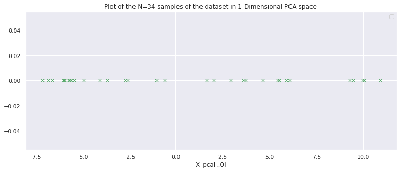

```
The explained variance for the first principle component is: [1.]
```

```python
### Plot of the N=34 samples of the dataset in 1-Dimensional PCA space ###

d = 1
X_pca, eigenvectors, eigenvalues = pca_function(F,d) #evec, evals, projections
val = 0.
ar = X_pca[:,0]

sns.set()

plt.figure(figsize=(13,5))
plt.plot(ar, np.zeros_like(ar) + val,"x", c='g')
plt.title("Plot of the N=34 samples of the dataset in 1-Dimensional PCA space ")
plt.xlabel("X_pca[:,0]")
plt.legend()
plt.show()

explained_variances = eigenvalues / eigenvalues.sum()
print('The explained variance for the first principle component is: {}'.format(explained_variances))
```

**d=2 dimensional PCA space**

```
No handles with labels found to put in legend.
```

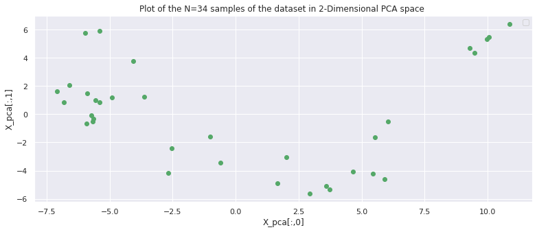

```
The explained variance for the first 2 principle components is: [0.72436226 0.27563774]
```

```python
### Plot of the N=34 samples of the dataset in 2-Dimensional PCA space ###

d = 2
X_pca, eigenvectors, eigenvalues = pca_function(F,d) #evec, evals, projections

sns.set()

plt.figure(figsize=(13,5))
plt.scatter(X_pca[:,0], X_pca[:,1], c='g')
plt.title("Plot of the N=34 samples of the dataset in 2-Dimensional PCA space ")
plt.xlabel("X_pca[:,0]")
plt.ylabel("X_pca[:,1]")
plt.legend()
plt.show()

explained_variances = eigenvalues / eigenvalues.sum()
print('The explained variance for the first 2 principle components is: {}'.format(explained_variances))
```

**d=3 dimensional PCA space**

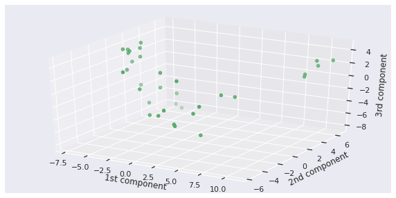

```
The explained variance for the first three principle components is: [0.58964354 0.22437394 0.18598252]
```

```python
### Plot of the N=34 samples of the dataset in 3-Dimensional PCA space ###
import matplotlib.pyplot as plt
from mpl_toolkits import mplot3d

d = 3
X_pca, eigenvectors, eigenvalues = pca_function(F,d) # evec, evals, projections

sns.set()

# fix our axis values
fig = plt.figure(figsize=(10, 5))
ax = fig.add_subplot(111, projection='3d')
xs = X_pca[:,0]
ys = X_pca[:,1]
zs = X_pca[:,2]

# plot
ax.scatter3D(xs, ys, zs, c='g')
ax.set_xlabel('1st component')
ax.set_ylabel('2nd component')
ax.set_zlabel('3rd component')
plt.show()

# compute explained variance
explained_variances = eigenvalues / eigenvalues.sum()
print('The explained variance for the first three principle components is: {}'.format(explained_variances))
```

**Comment**

## 2.2.2 Explained variance in PCA

Now we want to explore the proportion of explained variance of the PCA approximations of reduced dimensionality in the range for d in $[1,10]$.

Essentially, explained variance for one eigenvalue is just $\frac{e_i}{\sum_i e_i}$ for $e_i$ an eigenvalue of our feature matrix.

```python
### Loop to create vector of explained variance of the PCA for dimensions between 1 and 10 ###

e_var = []

for d in range(1,11):
    X_pca, eigenvectors, eigenvalues = pca_function(F,d)
    e_var.append(eigenvalues / eigenvalues.sum())

print("Explained variance is:", pd.DataFrame(e_var))
```

```
Explained variance is:           0         1         2  ...         7         8         9
0  1.000000       NaN       NaN  ...       NaN       NaN       NaN
1  0.724362  0.275638       NaN  ...       NaN       NaN       NaN
2  0.589644  0.224374  0.185983  ...       NaN       NaN       NaN
3  0.537290  0.204452  0.169469  ...       NaN       NaN       NaN
4  0.499294  0.189994  0.157485  ...       NaN       NaN       NaN
5  0.472425  0.179769  0.149010  ...       NaN       NaN       NaN
6  0.451933  0.171971  0.142546  ...       NaN       NaN       NaN
7  0.434250  0.165243  0.136969  ...  0.039126       NaN       NaN
8  0.419268  0.159542  0.132244  ...  0.037777  0.034501       NaN
9  0.405868  0.154443  0.128017  ...  0.036569  0.033398  0.031961

[10 rows x 10 columns]
```

**Comment**

Thanks to this table, we can see that the first 3 biggest eigenvalues account for more than 2/3 of the variability of the data when d=10, so we could make a fair assumption to reduce to d=3 when analysing data.

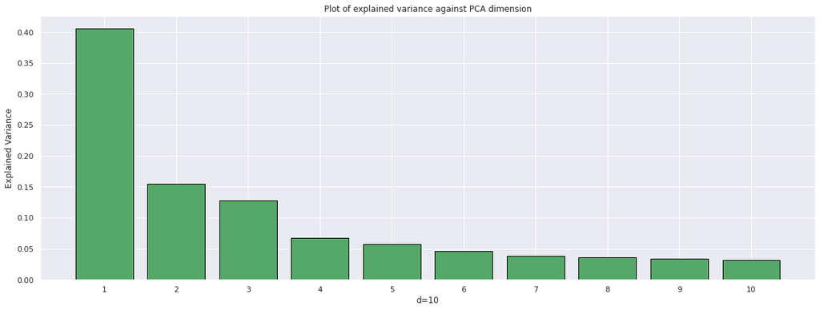

```python
### Plot of the explained variances of the PCA for dimensions between 1 and 10 ###

sns.set()

plt.figure(figsize=(20,7))
plt.bar(['1', '2', '3', '4', '5', '6', '7', '8', '9', '10'], e_var[9], color='g', edgecolor='black')
plt.xlabel('d=10')
plt.ylabel('Explained Variance')
plt.title('Plot of explained variance against PCA dimension')

plt.show()
```

**Comment**

The spectral decomposition of $F^TF$ is analogous to PCA as per lecture notes. Indeed PCA approximates our feature matrix to a lower rank matrix by taking the first k values from SVD. When we look at the plot for d=10, we see that clearly the first 3 components accounts for around 68% of the variability of the model. This is satisfying because more than two thirds of the data is explained in only 3 dimensions, compared to the 100 features in the beginning from which it was complicated to make inference from.

Mathematically speaking (from the PCA CT), we have that: the eigenvalues from the correlation matrix $\frac{1}{n-1}F^TF$ are the $\lambda_i$ and the eigenvalues of $F^TF$ (matrix of singular values) are the $s_i$. Essentially we have that $\lambda_i = s_i^2/(n-1)$.

The sum of all the eigenvalues represents the whole variance, hence that's why we look at explained variance, which is just $\frac{e_i}{\sum_i e_i}$.

Hence the conclusions from above.

# 2.3 Graph-based analysis

Now let's implement a graph based analysis of the adjacency matrix A which corresponds to friendships from the karate club.

## 2.3.0 Load data

```python
### LOAD NECESSARY PACKAGES ###
import numpy as np
import pandas as pd
import matplotlib.pyplot as plt
import scipy as sc
import networkx as nx
```

```python
### Adjacency matrix A ###
A = pd.read_csv("/content/karate_club_graph.csv")
A.drop(A.columns[[0]], axis=1, inplace=True) #delete first column
A.head()
```

|  | 0 | 1 | 2 | 3 | 4 | 5 | 6 | 7 | 8 | 9 | 10 | 11 | 12 | 13 | 14 | 15 | 16 | 17 | 18 | 19 | 20 | 21 | 22 | 23 | 24 | 25 | 26 | 27 | 28 | … |
| --- | --- | --- | --- | --- | --- | --- | --- | --- | --- | --- | --- | --- | --- | --- | --- | --- | --- | --- | --- | --- | --- | --- | --- | --- | --- | --- | --- | --- | --- | --- |
| 0 | 0.0 | 1.0 | 1.0 | 1.0 | 1.0 | 1.0 | 1.0 | 1.0 | 1.0 | 0.0 | 1.0 | 1.0 | 1.0 | 1.0 | 0.0 | 0.0 | 0.0 | 1.0 | 0.0 | 1.0 | 0.0 | 1.0 | 0.0 | 0.0 | 0.0 | 0.0 | 0.0 | 0.0 | 0.0 | … |
| 1 | 1.0 | 0.0 | 1.0 | 1.0 | 0.0 | 0.0 | 0.0 | 1.0 | 0.0 | 0.0 | 0.0 | 0.0 | 0.0 | 1.0 | 0.0 | 0.0 | 0.0 | 1.0 | 0.0 | 1.0 | 0.0 | 1.0 | 0.0 | 0.0 | 0.0 | 0.0 | 0.0 | 0.0 | 0.0 | … |
| 2 | 1.0 | 1.0 | 0.0 | 1.0 | 0.0 | 0.0 | 0.0 | 1.0 | 1.0 | 1.0 | 0.0 | 0.0 | 0.0 | 1.0 | 0.0 | 0.0 | 0.0 | 0.0 | 0.0 | 0.0 | 0.0 | 0.0 | 0.0 | 0.0 | 0.0 | 0.0 | 0.0 | 1.0 | 1.0 | … |
| 3 | 1.0 | 1.0 | 1.0 | 0.0 | 0.0 | 0.0 | 0.0 | 1.0 | 0.0 | 0.0 | 0.0 | 0.0 | 1.0 | 1.0 | 0.0 | 0.0 | 0.0 | 0.0 | 0.0 | 0.0 | 0.0 | 0.0 | 0.0 | 0.0 | 0.0 | 0.0 | 0.0 | 0.0 | 0.0 | … |
| 4 | 1.0 | 0.0 | 0.0 | 0.0 | 0.0 | 0.0 | 1.0 | 0.0 | 0.0 | 0.0 | 1.0 | 0.0 | 0.0 | 0.0 | 0.0 | 0.0 | 0.0 | 0.0 | 0.0 | 0.0 | 0.0 | 0.0 | 0.0 | 0.0 | 0.0 | 0.0 | 0.0 | 0.0 | 0.0 | … |

```python
A.shape
```

```
(34, 34)
```

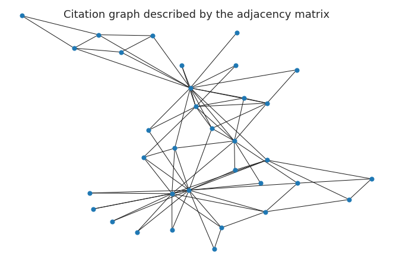

```python
### PLOT CITATION GRAPH FOR THE ADJACENCY MATRIX ###

import networkx as nx
plt.figure(figsize=(9,6))

# defining the graph
G = nx.from_numpy_matrix(np.array(A))

# drawing the citation graph
pos = nx.spring_layout(G)
nx.draw(G, pos, node_size=50)

plt.suptitle('Citation graph described by the adjacency matrix', fontsize=18)

plt.show()
```

## 2.3.1 Centralities

In this task we want to obtain 3 measures of centrality:

1. Degree Centrality: which computes the number of edges attached to one node (we divide it by twice the number of edges to normalise it as per the formula: $c_d = \frac{A\textbf{1}}{2E}$)
2. PageRank: which is a weighted random walk on the graph with the following formula: $c_{PR} = \alpha (AD^{-1})c_{PR} + (1- \alpha)\frac{1}{N} $, $\alpha \in [0,1]$ and setting $\alpha=0.85$ is a common practice
3. Eigenvector Centrality: which assigns higher centrality to nodes that are themselves connected to other highly central nodes: $Ac_e = \lambda c_e$

```python
### MAKE A INTO AN ARRAY ###
A = A.to_numpy()
```

```python
### Find degree of each node ###
degree = A.sum(axis=1)
degree
```

```
array([16.,  9., 10.,  6.,  3.,  4.,  4.,  4.,  5.,  2.,  3.,  1.,  2.,
        5.,  2.,  2.,  2.,  2.,  2.,  3.,  2.,  2.,  2.,  5.,  3.,  3.,
        2.,  4.,  3.,  4.,  4.,  6., 12., 17.])
```

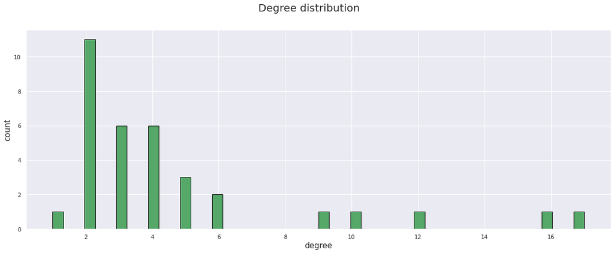

```python
### PLOT DISTRIBUTION OF DEGREE OF NODES ###

import seaborn as sns
sns.set() # degree distribution of graph

plt.figure(figsize=(20,7))
plt.hist(degree, bins=50, color='g', edgecolor='black')

plt.xlabel('degree', fontsize=15)
plt.ylabel('count', fontsize=15)
plt.suptitle('Degree distribution', fontsize=20)

plt.show()
```

**Comment**

Here we look at the distribution of the nodes against their degrees and we see that there are 11 nodes with degree 2 and then then there's a decreasing amount of nodes that have higher degrees.

**DEGREE CENTRALITY**

```python
### Degree Centrality function ###

def degree_centrality(A):

    N = A.shape[0]
    d = A @ np.ones(N)
    return d / np.sum(d)
```

```python
### DISPLAY DEGREE CENTRALITY VALUES ###
degree_list = degree_centrality(A)
pd.DataFrame(np.array(degree_list).reshape(1,34)).head()
```

|  | 0 | 1 | 2 | 3 | 4 | 5 | 6 | 7 | 8 | 9 | 10 | 11 | 12 | 13 | 14 | 15 | 16 | 17 | 18 | 19 | 20 | 21 | 22 | 23 | 24 | 25 | 26 | 27 | 28 | … |
| --- | --- | --- | --- | --- | --- | --- | --- | --- | --- | --- | --- | --- | --- | --- | --- | --- | --- | --- | --- | --- | --- | --- | --- | --- | --- | --- | --- | --- | --- | --- |
| 0 | 0.102564 | 0.057692 | 0.064103 | 0.038462 | 0.019231 | 0.025641 | 0.025641 | 0.025641 | 0.032051 | 0.012821 | 0.019231 | 0.00641 | 0.012821 | 0.032051 | 0.012821 | 0.012821 | 0.012821 | 0.012821 | 0.012821 | 0.019231 | 0.012821 | 0.012821 | 0.012821 | 0.032051 | 0.019231 | 0.019231 | 0.012821 | 0.025641 | 0.019231 | … |

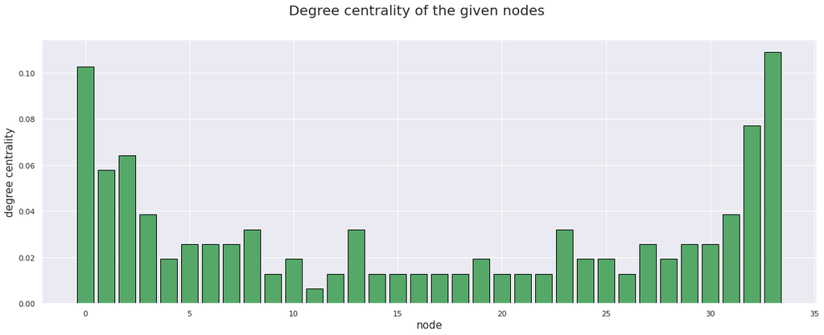

```python
### PLOT DEGREE CENTRALITY OF NODES ###

nodes = np.arange(0,34,1)

sns.set()

plt.figure(figsize=(20,7))
plt.bar(nodes,degree_list, color='g', edgecolor='black')

plt.xlabel('node', fontsize=15)
plt.ylabel('degree centrality', fontsize=15)
plt.suptitle('Degree centrality of the given nodes', fontsize=20)

plt.show()
```

```python
print('Node with maximal degree centrality:', nodes[np.argmax(degree_list)])
```

```
Node with maximal degree centrality: 33
```

**Comment**

Thanks to this plot of the distribution of the degreee centrality with respect to the node numbers, we can see that there are nodes which have the same degree centrality (when we rank them, note that we might get lists a bit varying even though it's ranking correctly), and some nodes stand out for particularly small or high values, such as node 11 has very small degree centrality and node 33 has highest degree centrality.

**PAGERANK**

```python
### PAGERANK FUNCTION ###

def trans_M(A):
    N1 = A.shape[0]
    d = A @ np.ones(N1)
    D = np.diag(d)
    M = np.linalg.inv(D)@A
    return M

def pagerank(A, num_iterations: int = 100, d: float = 0.85):
    M = (trans_M(A)).T
    N2 = M.shape[1]
    pr_cent = np.random.rand(N2, 1)
    pr_cent = pr_cent / np.linalg.norm(pr_cent, 1)
    M_pred = (d * M + (1 - d) / N2)

    for i in range(num_iterations):
        pr_cent = M_pred @ pr_cent
    return pr_cent.reshape(1,34).ravel()
```

```python
### DISPLAY PAGERANK VALUE ###
pagerank_list = pagerank(A)
pd.DataFrame(np.array(pagerank_list).reshape(1,34)).head()
```

|  | 0 | 1 | 2 | 3 | 4 | 5 | 6 | 7 | 8 | 9 | 10 | 11 | 12 | 13 | 14 | 15 | 16 | 17 | 18 | 19 | 20 | 21 | 22 | 23 | 24 | 25 | 26 | 27 | 28 | … |
| --- | --- | --- | --- | --- | --- | --- | --- | --- | --- | --- | --- | --- | --- | --- | --- | --- | --- | --- | --- | --- | --- | --- | --- | --- | --- | --- | --- | --- | --- | --- |
| 0 | 0.096997 | 0.052877 | 0.057079 | 0.03586 | 0.021978 | 0.029111 | 0.029111 | 0.02449 | 0.029766 | 0.014309 | 0.021978 | 0.009565 | 0.014645 | 0.029536 | 0.014536 | 0.014536 | 0.016784 | 0.014559 | 0.014536 | 0.019605 | 0.014536 | 0.014559 | 0.014536 | 0.031523 | 0.021076 | 0.021006 | 0.015044 | 0.02564 | 0.019573 | … |

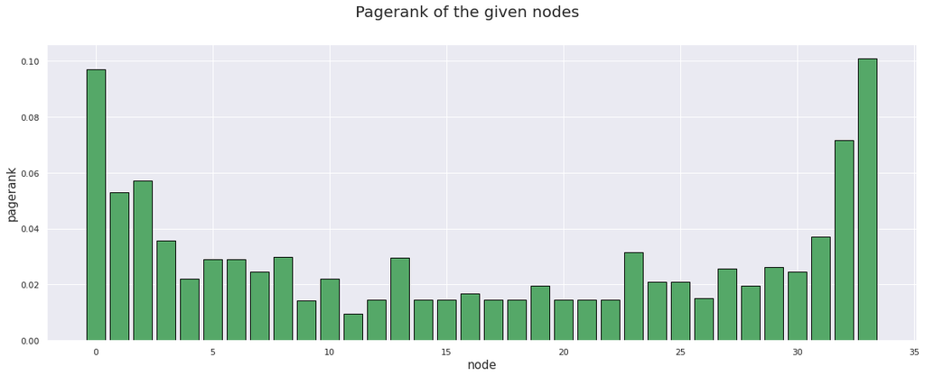

```python
### PLOT PAGERANK OF GIVEN NODES ###

nodes = np.arange(0,34,1)

sns.set()

plt.figure(figsize=(20,7))
plt.bar(nodes, pagerank_list, color='g', edgecolor='black')

plt.xlabel('node', fontsize=15)
plt.ylabel('pagerank', fontsize=15)
plt.suptitle('Pagerank of the given nodes', fontsize=20)

plt.show()
```

```python
print('Node with maximal pagerank:', nodes[np.argmax(pagerank_list)])
```

```
Node with maximal pagerank: 33
```

**Comment**

Similarly to the degree centrality distribution, we can see some nodes with the same pagerank values, and others standing out whether it's small or high values. This is because the graph isn't uniform and it allows to depict relationship between friends.

**EIGENVECTOR CENTRALITY**

```python
### Eigenvector Centrality function ###
from scipy.sparse import linalg

def eigenvector_centrality(A):
    eigenvalue, eigenvector = linalg.eigsh(A, 1, which="LM", return_eigenvectors=True)
    return np.abs(eigenvector).reshape(1,34).ravel()
```

```python
### DISPLAY EIGENVECTOR CENTRALITY ###
eigenvector_list = eigenvector_centrality(A)
pd.DataFrame(np.array(eigenvector_list).reshape(1,34)).head()
```

|  | 0 | 1 | 2 | 3 | 4 | 5 | 6 | 7 | 8 | 9 | 10 | 11 | 12 | 13 | 14 | 15 | 16 | 17 | 18 | 19 | 20 | 21 | 22 | 23 | 24 | 25 | 26 | 27 | 28 | … |
| --- | --- | --- | --- | --- | --- | --- | --- | --- | --- | --- | --- | --- | --- | --- | --- | --- | --- | --- | --- | --- | --- | --- | --- | --- | --- | --- | --- | --- | --- | --- |
| 0 | 0.355491 | 0.26596 | 0.317193 | 0.21118 | 0.075969 | 0.079483 | 0.079483 | 0.17096 | 0.227404 | 0.102674 | 0.075969 | 0.052856 | 0.084255 | 0.226473 | 0.101403 | 0.101403 | 0.023636 | 0.0924 | 0.101403 | 0.147913 | 0.101403 | 0.0924 | 0.101403 | 0.150119 | 0.057052 | 0.059206 | 0.075579 | 0.133477 | 0.131078 | … |

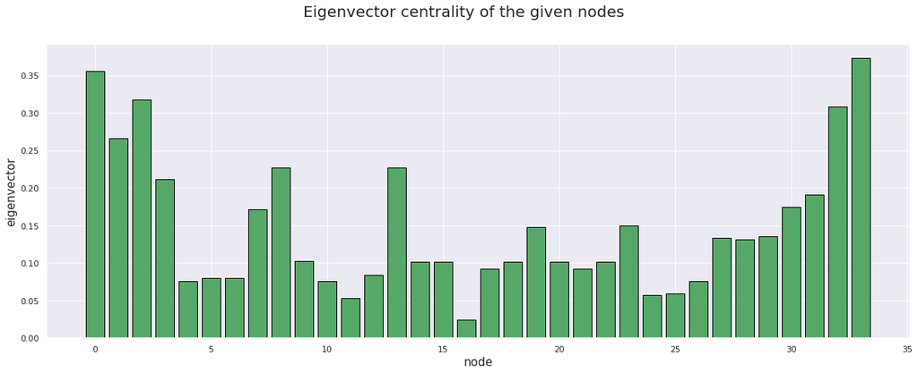

```python
### PLOT EIGENVECTOR CENTRALITY OF GIVEN NODES ###
nodes = np.arange(0,34,1)

sns.set()

plt.figure(figsize=(20,7))
plt.bar(nodes, eigenvector_list, color='g', edgecolor='black')

plt.xlabel('node', fontsize=15)
plt.ylabel('eigenvector', fontsize=15)
plt.suptitle('Eigenvector centrality of the given nodes', fontsize=20)

plt.show()
```

```python
print('Node with maximal eigenvector centrality:', nodes[np.argmax(eigenvector_list)])
```

```
Node with maximal eigenvector centrality: 33
```

**Comment**

Contrary to the degree centrality and the pagerank distributions, in the eigenvector centrality there are more values with higher eigenvector centrality in the middle nodes, while still having peaks at extremity nodes.

Now, we want to look at the similarity between the centrality measures and the associated node rankings.

```python
### DISPLAY IN A DATAFRAME THE VALUES AND PREVIEW###
B = np.array([degree_centrality(A), eigenvector_centrality(A), pagerank(A)])
B = pd.DataFrame(B.T)
B.columns = ['Degree', 'PageRank', 'Eigenvector Centrality']
B.head()
```

[output not shown]

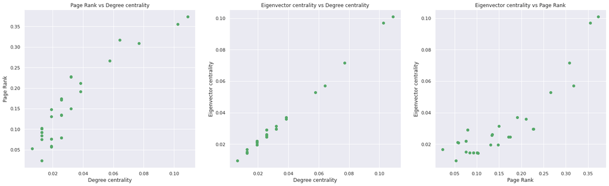

```python
### PLOT VALUES OF DEGREE CENTRALITIES AGAINST EACH OTHER  ###

B = B.to_numpy()

fig = plt.figure(figsize=(25, 7))

sns.set()

fig.add_subplot(131)
plt.scatter(B[:,0], B[:,1], c='g')
plt.xlabel("Degree centrality")
plt.ylabel("Page Rank")
plt.title("Page Rank vs Degree centrality")

fig.add_subplot(132)
plt.scatter(B[:,0], B[:,2], c='g')
plt.xlabel("Degree centrality")
plt.ylabel("Eigenvector centrality")
plt.title("Eigenvector centrality vs Degree centrality")

fig.add_subplot(133)
plt.scatter(B[:,1], B[:,2], c='g')
plt.xlabel("Page Rank")
plt.ylabel("Eigenvector centrality")
plt.title("Eigenvector centrality vs Page Rank")

plt.show()
```

**Comment**

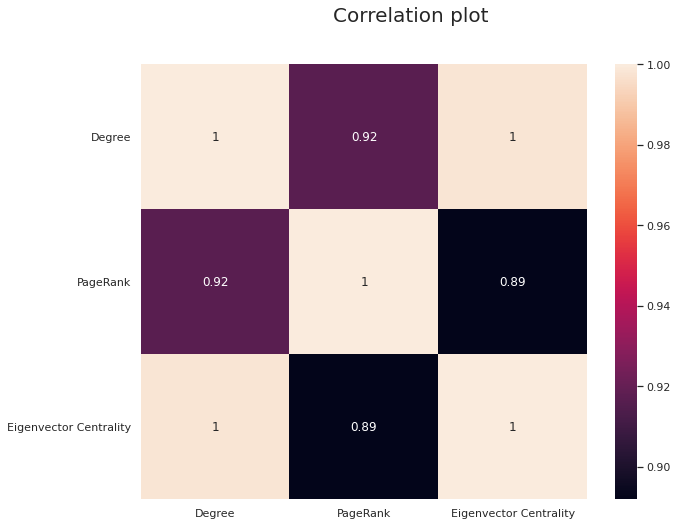

```python
### PLOT CORRELATION MATRIX OF THE VALUES ###

sns.set()

plt.figure(figsize=(10,8))

# computing correlation matrix of rankings
values_corr = pd.DataFrame(B).corr()

xy_labels = ['Degree', 'PageRank', 'Eigenvector Centrality']
ax = sns.heatmap(values_corr, annot=True, xticklabels=xy_labels, yticklabels=xy_labels)

plt.yticks(rotation = 0)
plt.suptitle('Correlation plot', fontsize=20)

plt.show()
```

**Comment**

And in general all these measures are highly correlated because they define some kind of centrality over the same graph.

However, what we want to look at is rather the ranking of the nodes associated to the order of the values of our centrality measures.

Now, let's look at the node rankings according to the different centrlaity measures:

```python
### SORT IN DESCENDING ORDER THE CENTRALITY MEASURES OF OUR GRAPH  ####

sorted_deg = np.array([x for _,x in sorted(zip(degree_centrality(A), nodes), reverse=True)])
sorted_pr = np.array([x for _,x in sorted(zip(pagerank(A), nodes), reverse=True)])
sorted_ec = np.array([x for _,x in sorted(zip(eigenvector_centrality(A), nodes), reverse=True)])
```

```python
### ORDER THE VALUES TO PLOT CORRELATION MATRIX ###

# initialization
rankings = np.zeros((len(sorted_pr),3))

# for loop
for i in range(len(sorted_pr)):
    # ranking for degree centrality
    rankings[sorted_deg[i],0] = i+1
    # ranking for pagerank
    rankings[sorted_pr[i],1] = i+1
    # ranking for eigenvector centrality
    rankings[sorted_ec[i],2] = i+1

# result
rankings_df = pd.DataFrame(rankings).head(30)
rankings_df.columns = ['Degree','PageRank','Eigenvector Centrality']
rankings_df.head()
```

|  | Degree | PageRank | Eigenvector Centrality |
| --- | --- | --- | --- |
| 0 | 2.0 | 2.0 | 2.0 |
| 1 | 5.0 | 5.0 | 5.0 |
| 2 | 4.0 | 4.0 | 3.0 |
| 3 | 7.0 | 7.0 | 8.0 |
| 4 | 22.0 | 18.0 | 29.0 |

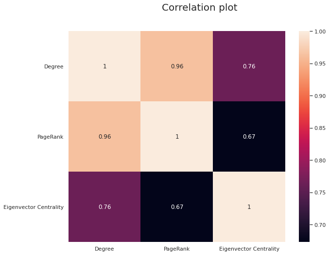

```python
### PLOT CORRELATION MATRIX OF THE RANKINGS

sns.set()

plt.figure(figsize=(10,8))

# computing correlation matrix of rankings
ranking_corr = pd.DataFrame(rankings).corr()

xy_labels = ['Degree', 'PageRank', 'Eigenvector Centrality']
ax = sns.heatmap(ranking_corr, annot=True, xticklabels=xy_labels, yticklabels=xy_labels)

plt.yticks(rotation = 0)
plt.suptitle('Correlation plot', fontsize=20)

plt.show()
```

**Comment on confusion matrix**

Clearly we can see that there is a high correlation in the node rankings for PageRank and degree centrality, whilst less obvious for degree and eigenvector centrality, and pagerank and eigenvector centrality.

In general these three methods are quite different so it's not that surprising that it's not all highly correlated.